# Porject 4. Wrangle and Analyze Data

## Introduction

Real-world data rarely comes clean, such as the tweet archive of Twitter user @dog_rates, also known as WeRateDogs. WeRateDogs is a Twitter account that rates people's dogs with a humorous comment about the dog.

In this project, I will be wrangling, analyzing, and visualizing WeRateDogs as following processes:

1. Wrangling data
   - Gathering data
   - Assessing data
   - Cleaning data
2. Storing, analyzing, and visualizing your wrangled data
3. Reporting on
   - Data wrangling efforts
   - Data analyses and visualizations

## Data Wrangling

```python
# Import all libraries needed in this project

import numpy as np
import pandas as pd
import requests
import tweepy
import json
from timeit import default_timer as timer
from datetime import datetime
import seaborn as sns
import matplotlib.pyplot as plt
%matplotlib inline
```

### I. Gathering Data

Gather each of the three pieces of data as described below:

1. Manually download WeRateDogs twitter archive (**twitter_archive_enhanced.csv**) on hand, which contains basic tweet data including tweet ID, ratings, dog name and dog stage.
2. Using the Requests library and the provided URL programmatically download the tweet image predictions named as **image_predictions.tsv** hosted on Udacity's servers.
3. Query the Twitter API to download each tweet’s JSON data and extract the favorite and retweet counts for each tweet, and store each tweet's entire set of JSON data in a file called tweet_json.txt file.

#### 1. Manually download and read WeRateDogs twitter archive

```python
# Read WeRateDogs twitter archive provided by Udacity
twitter_archive_enhanced = pd.read_csv('twitter-archive-enhanced.csv')
```

```python
# Later the tweet IDs in the WeRateDogs Twitter archive will be used to query the Twitter API for each tweet's JSON data
tweet_id = twitter_archive_enhanced["tweet_id"]
tweet_id.head()
```

```
0    892420643555336193
1    892177421306343426
2    891815181378084864
3    891689557279858688
4    891327558926688256
Name: tweet_id, dtype: int64
```

#### 2. Programmatically download tweet image predicitons

```python
# Using the Requests library and the provided URL to download the tweet image predictions
url = "https://d17h27t6h515a5.cloudfront.net/topher/2017/August/599fd2ad_image-predictions/image-predictions.tsv"
r = requests.get(url)
with open(url.split('/')[-1],'wb') as f:
    f.write(r.content)
image_predictions = pd.read_csv('image-predictions.tsv', sep='\t')
```

#### 3. Access the Twitter API using tweepy with OAuth method

```python
# Consumer keys and access tokens, used for OAuth
consumer_key = 'my consumer key'
consumer_secret = 'my consumer_secret'
access_token = 'my access token'
access_secret = 'my access_secret'

# Authenticate to Twitter using the keys and tokens
auth = tweepy.OAuthHandler(consumer_key, consumer_secret)
auth.set_access_token(access_token, access_secret)

# Create API object
api = tweepy.API(auth,
                 parser = tweepy.parsers.JSONParser(), # Parse the response from Twitter to Json Object
                 wait_on_rate_limit = True,  # Twitter's API has a rate limit. Rate limits are divided into 15 minute intervals
                 wait_on_rate_limit_notify = True)
```

```python
# Using first tweet id in the WeRateDogs Twitter archive to get to know what kind of data available via Twitter's API
tweet = api.get_status(tweet_id[0])
tweet
```

[output not shown]

[output cut: 44 more lines]

```
  'follow_request_sent': False,
  'notifications': False,
  'translator_type': 'none'},
 'geo': None,
 'coordinates': None,
 'place': None,
 'contributors': None,
 'is_quote_status': False,
 'retweet_count': 7979,
 'favorite_count': 37245,
 'favorited': False,
 'retweeted': False,
 'possibly_sensitive': False,
 'possibly_sensitive_appealable': False,
 'lang': 'en'}
```

```python
# Tweet IDs for which to gather additional data via Twitter's API
tweet_ids = twitter_archive_enhanced["tweet_id"]
len(tweet_ids)

# Query Twitter's API for JSON data for each tweet ID in the Twitter archive
count = 0
fails_dict = {}
start = timer()
# Save each tweet's returned JSON as a new line in the tweet_json.txt file
with open('tweet_json.txt', 'w') as outfile:
    # This loop will likely take 20-30 minutes to run because of Twitter's rate limit
    for tweet_id in tweet_ids:
        count += 1
        print(str(count) + ": " + str(tweet_id))
        try:
            tweet = api.get_status(tweet_id, tweet_mode='extended')
            print("Success")
            json.dump(tweet, outfile)
            outfile.write('\n')
        except tweepy.TweepError as e:
            print("Fail")
            fails_dict[tweet_id] = e
            pass
end = timer()
print(end - start) # Measure the execution time in seconds
print(fails_dict)
```

[output not shown]

[output cut: 1740 more lines]

[output not shown]

```
Rate limit reached. Sleeping for: 126
```

[output not shown]

[output cut: 1745 more lines]

[output not shown]

```
Rate limit reached. Sleeping for: 687
```

[output not shown]

[output cut: 1064 more lines]

[output not shown]

```python
# Calculate how many tweets saved
print(count - len(fails_dict))
```

```
2333
```

```python
# Set up a list of dictionaries containing tweet_id, retweet_count and favorite_count, and later convert this list to a DataFram
tweet_list = []
# Read this tweet_json.tx file line by line into a pandas DataFrame with tweet ID, retweet count, and favorite count
with open('tweet_json.txt','r')as file:
    for line in file:
        json_read = json.loads(line)
        tweet_id = json_read["id"]
        favorite_count = json_read["favorite_count"]
        retweet_count  = json_read["retweet_count"]
        tweet_list.append({'tweet_id': tweet_id,
                        'favorite_count': favorite_count,
                        'retweet_count': retweet_count
                       })
tweet_df = pd.DataFrame(tweet_list, columns = ['tweet_id', 'favorite_count', 'retweet_count'])
tweet_df.head()
```

|  | tweet_id | favorite_count | retweet_count |
| --- | --- | --- | --- |
| 0 | 892420643555336193 | 37241 | 7978 |
| 1 | 892177421306343426 | 32022 | 5925 |
| 2 | 891815181378084864 | 24126 | 3913 |
| 3 | 891689557279858688 | 40558 | 8127 |
| 4 | 891327558926688256 | 38792 | 8811 |

```python
tweet_df.info()
```

```
<class 'pandas.core.frame.DataFrame'>
RangeIndex: 2333 entries, 0 to 2332
Data columns (total 3 columns):
tweet_id          2333 non-null int64
favorite_count    2333 non-null int64
retweet_count     2333 non-null int64
dtypes: int64(3)
memory usage: 54.8 KB
```

### II. Assessing Data

After gathering three datasets including **twitter_archive_enhanced** from enhanced twitter archive, **image_predictions** from image predictions file, and **tweet_df** for additional data via the twitter API, assess them visually and programmatically for quality and tidiness issues.

#### A. Table twitter_archive_enhanced

```python
# Display the twitter_archive_enhanced table
twitter_archive_enhanced
```

|  | tweet_id | in_reply_to_status_id | in_reply_to_user_id | timestamp | source | text | retweeted_status_id | retweeted_status_user_id | retweeted_status_timestamp | expanded_urls | rating_numerator | rating_denominator | name | doggo | floofer | pupper | puppo |
| --- | --- | --- | --- | --- | --- | --- | --- | --- | --- | --- | --- | --- | --- | --- | --- | --- | --- |
| 0 | 892420643555336193 | NaN | NaN | 2017-08-01 16:23:56 +0000 | <a href="http://twitter.com/download/iphone" r... | This is Phineas. He's a mystical boy. Only eve... | NaN | NaN | NaN | https://twitter.com/dog_rates/status/892420643... | 13 | 10 | Phineas | None | None | None | None |
| 1 | 892177421306343426 | NaN | NaN | 2017-08-01 00:17:27 +0000 | <a href="http://twitter.com/download/iphone" r... | This is Tilly. She's just checking pup on you.... | NaN | NaN | NaN | https://twitter.com/dog_rates/status/892177421... | 13 | 10 | Tilly | None | None | None | None |
| 2 | 891815181378084864 | NaN | NaN | 2017-07-31 00:18:03 +0000 | <a href="http://twitter.com/download/iphone" r... | This is Archie. He is a rare Norwegian Pouncin... | NaN | NaN | NaN | https://twitter.com/dog_rates/status/891815181... | 12 | 10 | Archie | None | None | None | None |
| 3 | 891689557279858688 | NaN | NaN | 2017-07-30 15:58:51 +0000 | <a href="http://twitter.com/download/iphone" r... | This is Darla. She commenced a snooze mid meal... | NaN | NaN | NaN | https://twitter.com/dog_rates/status/891689557... | 13 | 10 | Darla | None | None | None | None |
| 4 | 891327558926688256 | NaN | NaN | 2017-07-29 16:00:24 +0000 | <a href="http://twitter.com/download/iphone" r... | This is Franklin. He would like you to stop ca... | NaN | NaN | NaN | https://twitter.com/dog_rates/status/891327558... | 12 | 10 | Franklin | None | None | None | None |
| 5 | 891087950875897856 | NaN | NaN | 2017-07-29 00:08:17 +0000 | <a href="http://twitter.com/download/iphone" r... | Here we have a majestic great white breaching ... | NaN | NaN | NaN | https://twitter.com/dog_rates/status/891087950... | 13 | 10 | None | None | None | None | None |
| 6 | 890971913173991426 | NaN | NaN | 2017-07-28 16:27:12 +0000 | <a href="http://twitter.com/download/iphone" r... | Meet Jax. He enjoys ice cream so much he gets ... | NaN | NaN | NaN | https://gofundme.com/ydvmve-surgery-for-jax,ht... | 13 | 10 | Jax | None | None | None | None |
| 7 | 890729181411237888 | NaN | NaN | 2017-07-28 00:22:40 +0000 | <a href="http://twitter.com/download/iphone" r... | When you watch your owner call another dog a g... | NaN | NaN | NaN | https://twitter.com/dog_rates/status/890729181... | 13 | 10 | None | None | None | None | None |
| 8 | 890609185150312448 | NaN | NaN | 2017-07-27 16:25:51 +0000 | <a href="http://twitter.com/download/iphone" r... | This is Zoey. She doesn't want to be one of th... | NaN | NaN | NaN | https://twitter.com/dog_rates/status/890609185... | 13 | 10 | Zoey | None | None | None | None |
| 9 | 890240255349198849 | NaN | NaN | 2017-07-26 15:59:51 +0000 | <a href="http://twitter.com/download/iphone" r... | This is Cassie. She is a college pup. Studying... | NaN | NaN | NaN | https://twitter.com/dog_rates/status/890240255... | 14 | 10 | Cassie | doggo | None | None | None |
| 10 | 890006608113172480 | NaN | NaN | 2017-07-26 00:31:25 +0000 | <a href="http://twitter.com/download/iphone" r... | This is Koda. He is a South Australian decksha... | NaN | NaN | NaN | https://twitter.com/dog_rates/status/890006608... | 13 | 10 | Koda | None | None | None | None |
| 11 | 889880896479866881 | NaN | NaN | 2017-07-25 16:11:53 +0000 | <a href="http://twitter.com/download/iphone" r... | This is Bruno. He is a service shark. Only get... | NaN | NaN | NaN | https://twitter.com/dog_rates/status/889880896... | 13 | 10 | Bruno | None | None | None | None |
| 12 | 889665388333682689 | NaN | NaN | 2017-07-25 01:55:32 +0000 | <a href="http://twitter.com/download/iphone" r... | Here's a puppo that seems to be on the fence a... | NaN | NaN | NaN | https://twitter.com/dog_rates/status/889665388... | 13 | 10 | None | None | None | None | puppo |
| 13 | 889638837579907072 | NaN | NaN | 2017-07-25 00:10:02 +0000 | <a href="http://twitter.com/download/iphone" r... | This is Ted. He does his best. Sometimes that'... | NaN | NaN | NaN | https://twitter.com/dog_rates/status/889638837... | 12 | 10 | Ted | None | None | None | None |
| 14 | 889531135344209921 | NaN | NaN | 2017-07-24 17:02:04 +0000 | <a href="http://twitter.com/download/iphone" r... | This is Stuart. He's sporting his favorite fan... | NaN | NaN | NaN | https://twitter.com/dog_rates/status/889531135... | 13 | 10 | Stuart | None | None | None | puppo |
| 15 | 889278841981685760 | NaN | NaN | 2017-07-24 00:19:32 +0000 | <a href="http://twitter.com/download/iphone" r... | This is Oliver. You're witnessing one of his m... | NaN | NaN | NaN | https://twitter.com/dog_rates/status/889278841... | 13 | 10 | Oliver | None | None | None | None |
| 16 | 888917238123831296 | NaN | NaN | 2017-07-23 00:22:39 +0000 | <a href="http://twitter.com/download/iphone" r... | This is Jim. He found a fren. Taught him how t... | NaN | NaN | NaN | https://twitter.com/dog_rates/status/888917238... | 12 | 10 | Jim | None | None | None | None |
| 17 | 888804989199671297 | NaN | NaN | 2017-07-22 16:56:37 +0000 | <a href="http://twitter.com/download/iphone" r... | This is Zeke. He has a new stick. Very proud o... | NaN | NaN | NaN | https://twitter.com/dog_rates/status/888804989... | 13 | 10 | Zeke | None | None | None | None |
| 18 | 888554962724278272 | NaN | NaN | 2017-07-22 00:23:06 +0000 | <a href="http://twitter.com/download/iphone" r... | This is Ralphus. He's powering up. Attempting ... | NaN | NaN | NaN | https://twitter.com/dog_rates/status/888554962... | 13 | 10 | Ralphus | None | None | None | None |
| 19 | 888202515573088257 | NaN | NaN | 2017-07-21 01:02:36 +0000 | <a href="http://twitter.com/download/iphone" r... | RT @dog_rates: This is Canela. She attempted s... | 8.874740e+17 | 4.196984e+09 | 2017-07-19 00:47:34 +0000 | https://twitter.com/dog_rates/status/887473957... | 13 | 10 | Canela | None | None | None | None |
| 20 | 888078434458587136 | NaN | NaN | 2017-07-20 16:49:33 +0000 | <a href="http://twitter.com/download/iphone" r... | This is Gerald. He was just told he didn't get... | NaN | NaN | NaN | https://twitter.com/dog_rates/status/888078434... | 12 | 10 | Gerald | None | None | None | None |
| 21 | 887705289381826560 | NaN | NaN | 2017-07-19 16:06:48 +0000 | <a href="http://twitter.com/download/iphone" r... | This is Jeffrey. He has a monopoly on the pool... | NaN | NaN | NaN | https://twitter.com/dog_rates/status/887705289... | 13 | 10 | Jeffrey | None | None | None | None |
| 22 | 887517139158093824 | NaN | NaN | 2017-07-19 03:39:09 +0000 | <a href="http://twitter.com/download/iphone" r... | I've yet to rate a Venezuelan Hover Wiener. Th... | NaN | NaN | NaN | https://twitter.com/dog_rates/status/887517139... | 14 | 10 | such | None | None | None | None |
| 23 | 887473957103951883 | NaN | NaN | 2017-07-19 00:47:34 +0000 | <a href="http://twitter.com/download/iphone" r... | This is Canela. She attempted some fancy porch... | NaN | NaN | NaN | https://twitter.com/dog_rates/status/887473957... | 13 | 10 | Canela | None | None | None | None |
| 24 | 887343217045368832 | NaN | NaN | 2017-07-18 16:08:03 +0000 | <a href="http://twitter.com/download/iphone" r... | You may not have known you needed to see this ... | NaN | NaN | NaN | https://twitter.com/dog_rates/status/887343217... | 13 | 10 | None | None | None | None | None |
| 25 | 887101392804085760 | NaN | NaN | 2017-07-18 00:07:08 +0000 | <a href="http://twitter.com/download/iphone" r... | This... is a Jubilant Antarctic House Bear. We... | NaN | NaN | NaN | https://twitter.com/dog_rates/status/887101392... | 12 | 10 | None | None | None | None | None |
| 26 | 886983233522544640 | NaN | NaN | 2017-07-17 16:17:36 +0000 | <a href="http://twitter.com/download/iphone" r... | This is Maya. She's very shy. Rarely leaves he... | NaN | NaN | NaN | https://twitter.com/dog_rates/status/886983233... | 13 | 10 | Maya | None | None | None | None |
| 27 | 886736880519319552 | NaN | NaN | 2017-07-16 23:58:41 +0000 | <a href="http://twitter.com/download/iphone" r... | This is Mingus. He's a wonderful father to his... | NaN | NaN | NaN | https://www.gofundme.com/mingusneedsus,https:/... | 13 | 10 | Mingus | None | None | None | None |
| 28 | 886680336477933568 | NaN | NaN | 2017-07-16 20:14:00 +0000 | <a href="http://twitter.com/download/iphone" r... | This is Derek. He's late for a dog meeting. 13... | NaN | NaN | NaN | https://twitter.com/dog_rates/status/886680336... | 13 | 10 | Derek | None | None | None | None |
| 29 | 886366144734445568 | NaN | NaN | 2017-07-15 23:25:31 +0000 | <a href="http://twitter.com/download/iphone" r... | This is Roscoe. Another pupper fallen victim t... | NaN | NaN | NaN | https://twitter.com/dog_rates/status/886366144... | 12 | 10 | Roscoe | None | None | pupper | None |
| ... | ... | ... | ... | ... | ... | ... | ... | ... | ... | ... | ... | ... | ... | ... | ... | ... | ... |
| 2326 | 666411507551481857 | NaN | NaN | 2015-11-17 00:24:19 +0000 | <a href="http://twitter.com/download/iphone" r... | This is quite the dog. Gets really excited whe... | NaN | NaN | NaN | https://twitter.com/dog_rates/status/666411507... | 2 | 10 | quite | None | None | None | None |
| 2327 | 666407126856765440 | NaN | NaN | 2015-11-17 00:06:54 +0000 | <a href="http://twitter.com/download/iphone" r... | This is a southern Vesuvius bumblegruff. Can d... | NaN | NaN | NaN | https://twitter.com/dog_rates/status/666407126... | 7 | 10 | a | None | None | None | None |
| 2328 | 666396247373291520 | NaN | NaN | 2015-11-16 23:23:41 +0000 | <a href="http://twitter.com/download/iphone" r... | Oh goodness. A super rare northeast Qdoba kang... | NaN | NaN | NaN | https://twitter.com/dog_rates/status/666396247... | 9 | 10 | None | None | None | None | None |
| 2329 | 666373753744588802 | NaN | NaN | 2015-11-16 21:54:18 +0000 | <a href="http://twitter.com/download/iphone" r... | Those are sunglasses and a jean jacket. 11/10 ... | NaN | NaN | NaN | https://twitter.com/dog_rates/status/666373753... | 11 | 10 | None | None | None | None | None |
| 2330 | 666362758909284353 | NaN | NaN | 2015-11-16 21:10:36 +0000 | <a href="http://twitter.com/download/iphone" r... | Unique dog here. Very small. Lives in containe... | NaN | NaN | NaN | https://twitter.com/dog_rates/status/666362758... | 6 | 10 | None | None | None | None | None |
| 2331 | 666353288456101888 | NaN | NaN | 2015-11-16 20:32:58 +0000 | <a href="http://twitter.com/download/iphone" r... | Here we have a mixed Asiago from the Galápagos... | NaN | NaN | NaN | https://twitter.com/dog_rates/status/666353288... | 8 | 10 | None | None | None | None | None |
| 2332 | 666345417576210432 | NaN | NaN | 2015-11-16 20:01:42 +0000 | <a href="http://twitter.com/download/iphone" r... | Look at this jokester thinking seat belt laws ... | NaN | NaN | NaN | https://twitter.com/dog_rates/status/666345417... | 10 | 10 | None | None | None | None | None |
| 2333 | 666337882303524864 | NaN | NaN | 2015-11-16 19:31:45 +0000 | <a href="http://twitter.com/download/iphone" r... | This is an extremely rare horned Parthenon. No... | NaN | NaN | NaN | https://twitter.com/dog_rates/status/666337882... | 9 | 10 | an | None | None | None | None |
| 2334 | 666293911632134144 | NaN | NaN | 2015-11-16 16:37:02 +0000 | <a href="http://twitter.com/download/iphone" r... | This is a funny dog. Weird toes. Won't come do... | NaN | NaN | NaN | https://twitter.com/dog_rates/status/666293911... | 3 | 10 | a | None | None | None | None |
| 2335 | 666287406224695296 | NaN | NaN | 2015-11-16 16:11:11 +0000 | <a href="http://twitter.com/download/iphone" r... | This is an Albanian 3 1/2 legged Episcopalian... | NaN | NaN | NaN | https://twitter.com/dog_rates/status/666287406... | 1 | 2 | an | None | None | None | None |
| 2336 | 666273097616637952 | NaN | NaN | 2015-11-16 15:14:19 +0000 | <a href="http://twitter.com/download/iphone" r... | Can take selfies 11/10 https://t.co/ws2AMaNwPW | NaN | NaN | NaN | https://twitter.com/dog_rates/status/666273097... | 11 | 10 | None | None | None | None | None |
| 2337 | 666268910803644416 | NaN | NaN | 2015-11-16 14:57:41 +0000 | <a href="http://twitter.com/download/iphone" r... | Very concerned about fellow dog trapped in com... | NaN | NaN | NaN | https://twitter.com/dog_rates/status/666268910... | 10 | 10 | None | None | None | None | None |
| 2338 | 666104133288665088 | NaN | NaN | 2015-11-16 04:02:55 +0000 | <a href="http://twitter.com/download/iphone" r... | Not familiar with this breed. No tail (weird).... | NaN | NaN | NaN | https://twitter.com/dog_rates/status/666104133... | 1 | 10 | None | None | None | None | None |
| 2339 | 666102155909144576 | NaN | NaN | 2015-11-16 03:55:04 +0000 | <a href="http://twitter.com/download/iphone" r... | Oh my. Here you are seeing an Adobe Setter giv... | NaN | NaN | NaN | https://twitter.com/dog_rates/status/666102155... | 11 | 10 | None | None | None | None | None |
| 2340 | 666099513787052032 | NaN | NaN | 2015-11-16 03:44:34 +0000 | <a href="http://twitter.com/download/iphone" r... | Can stand on stump for what seems like a while... | NaN | NaN | NaN | https://twitter.com/dog_rates/status/666099513... | 8 | 10 | None | None | None | None | None |
| 2341 | 666094000022159362 | NaN | NaN | 2015-11-16 03:22:39 +0000 | <a href="http://twitter.com/download/iphone" r... | This appears to be a Mongolian Presbyterian mi... | NaN | NaN | NaN | https://twitter.com/dog_rates/status/666094000... | 9 | 10 | None | None | None | None | None |
| 2342 | 666082916733198337 | NaN | NaN | 2015-11-16 02:38:37 +0000 | <a href="http://twitter.com/download/iphone" r... | Here we have a well-established sunblockerspan... | NaN | NaN | NaN | https://twitter.com/dog_rates/status/666082916... | 6 | 10 | None | None | None | None | None |
| 2343 | 666073100786774016 | NaN | NaN | 2015-11-16 01:59:36 +0000 | <a href="http://twitter.com/download/iphone" r... | Let's hope this flight isn't Malaysian (lol). ... | NaN | NaN | NaN | https://twitter.com/dog_rates/status/666073100... | 10 | 10 | None | None | None | None | None |
| 2344 | 666071193221509120 | NaN | NaN | 2015-11-16 01:52:02 +0000 | <a href="http://twitter.com/download/iphone" r... | Here we have a northern speckled Rhododendron.... | NaN | NaN | NaN | https://twitter.com/dog_rates/status/666071193... | 9 | 10 | None | None | None | None | None |
| 2345 | 666063827256086533 | NaN | NaN | 2015-11-16 01:22:45 +0000 | <a href="http://twitter.com/download/iphone" r... | This is the happiest dog you will ever see. Ve... | NaN | NaN | NaN | https://twitter.com/dog_rates/status/666063827... | 10 | 10 | the | None | None | None | None |
| 2346 | 666058600524156928 | NaN | NaN | 2015-11-16 01:01:59 +0000 | <a href="http://twitter.com/download/iphone" r... | Here is the Rand Paul of retrievers folks! He'... | NaN | NaN | NaN | https://twitter.com/dog_rates/status/666058600... | 8 | 10 | the | None | None | None | None |
| 2347 | 666057090499244032 | NaN | NaN | 2015-11-16 00:55:59 +0000 | <a href="http://twitter.com/download/iphone" r... | My oh my. This is a rare blond Canadian terrie... | NaN | NaN | NaN | https://twitter.com/dog_rates/status/666057090... | 9 | 10 | a | None | None | None | None |
| 2348 | 666055525042405380 | NaN | NaN | 2015-11-16 00:49:46 +0000 | <a href="http://twitter.com/download/iphone" r... | Here is a Siberian heavily armored polar bear ... | NaN | NaN | NaN | https://twitter.com/dog_rates/status/666055525... | 10 | 10 | a | None | None | None | None |
| 2349 | 666051853826850816 | NaN | NaN | 2015-11-16 00:35:11 +0000 | <a href="http://twitter.com/download/iphone" r... | This is an odd dog. Hard on the outside but lo... | NaN | NaN | NaN | https://twitter.com/dog_rates/status/666051853... | 2 | 10 | an | None | None | None | None |
| 2350 | 666050758794694657 | NaN | NaN | 2015-11-16 00:30:50 +0000 | <a href="http://twitter.com/download/iphone" r... | This is a truly beautiful English Wilson Staff... | NaN | NaN | NaN | https://twitter.com/dog_rates/status/666050758... | 10 | 10 | a | None | None | None | None |
| 2351 | 666049248165822465 | NaN | NaN | 2015-11-16 00:24:50 +0000 | <a href="http://twitter.com/download/iphone" r... | Here we have a 1949 1st generation vulpix. Enj... | NaN | NaN | NaN | https://twitter.com/dog_rates/status/666049248... | 5 | 10 | None | None | None | None | None |
| 2352 | 666044226329800704 | NaN | NaN | 2015-11-16 00:04:52 +0000 | <a href="http://twitter.com/download/iphone" r... | This is a purebred Piers Morgan. Loves to Netf... | NaN | NaN | NaN | https://twitter.com/dog_rates/status/666044226... | 6 | 10 | a | None | None | None | None |
| 2353 | 666033412701032449 | NaN | NaN | 2015-11-15 23:21:54 +0000 | <a href="http://twitter.com/download/iphone" r... | Here is a very happy pup. Big fan of well-main... | NaN | NaN | NaN | https://twitter.com/dog_rates/status/666033412... | 9 | 10 | a | None | None | None | None |
| 2354 | 666029285002620928 | NaN | NaN | 2015-11-15 23:05:30 +0000 | <a href="http://twitter.com/download/iphone" r... | This is a western brown Mitsubishi terrier. Up... | NaN | NaN | NaN | https://twitter.com/dog_rates/status/666029285... | 7 | 10 | a | None | None | None | None |
| 2355 | 666020888022790149 | NaN | NaN | 2015-11-15 22:32:08 +0000 | <a href="http://twitter.com/download/iphone" r... | Here we have a Japanese Irish Setter. Lost eye... | NaN | NaN | NaN | https://twitter.com/dog_rates/status/666020888... | 8 | 10 | None | None | None | None | None |

2356 rows × 17 columns

```python
twitter_archive_enhanced.info()
```

```
<class 'pandas.core.frame.DataFrame'>
RangeIndex: 2356 entries, 0 to 2355
Data columns (total 17 columns):
tweet_id                      2356 non-null int64
in_reply_to_status_id         78 non-null float64
in_reply_to_user_id           78 non-null float64
timestamp                     2356 non-null object
source                        2356 non-null object
text                          2356 non-null object
retweeted_status_id           181 non-null float64
retweeted_status_user_id      181 non-null float64
retweeted_status_timestamp    181 non-null object
expanded_urls                 2297 non-null object
rating_numerator              2356 non-null int64
rating_denominator            2356 non-null int64
name                          2356 non-null object
doggo                         2356 non-null object
floofer                       2356 non-null object
pupper                        2356 non-null object
puppo                         2356 non-null object
dtypes: float64(4), int64(3), object(10)
memory usage: 313.0+ KB
```

```python
twitter_archive_enhanced.rating_denominator.value_counts()
```

```
10     2333
11        3
50        3
80        2
20        2
2         1
16        1
40        1
70        1
15        1
90        1
110       1
120       1
130       1
150       1
170       1
7         1
0         1
Name: rating_denominator, dtype: int64
```

```python
twitter_archive_enhanced.rating_numerator.value_counts()
```

```
12      558
11      464
10      461
13      351
9       158
8       102
7        55
14       54
5        37
6        32
3        19
4        17
1         9
2         9
420       2
```

[output cut: 26 more lines]

```python
twitter_archive_enhanced.query("rating_numerator > 15" or "rating_denminator != 10" )[["text", "rating_numerator","rating_denominator"]]
```

|  | text | rating_numerator | rating_denominator |
| --- | --- | --- | --- |
| 55 | @roushfenway These are good dogs but 17/10 is an emotional impulse rating. More like 13/10s | 17 | 10 |
| 188 | @dhmontgomery We also gave snoop dogg a 420/10 but I think that predated your research | 420 | 10 |
| 189 | @s8n You tried very hard to portray this good boy as not so good, but you have ultimately failed. His goodness shines through. 666/10 | 666 | 10 |
| 290 | @markhoppus 182/10 | 182 | 10 |
| 313 | @jonnysun @Lin_Manuel ok jomny I know you're excited but 960/00 isn't a valid rating, 13/10 is tho | 960 | 0 |
| 340 | RT @dog_rates: This is Logan, the Chow who lived. He solemnly swears he's up to lots of good. H*ckin magical af 9.75/10 https://t.co/yBO5wu… | 75 | 10 |
| 433 | The floofs have been released I repeat the floofs have been released. 84/70 https://t.co/NIYC820tmd | 84 | 70 |
| 516 | Meet Sam. She smiles 24/7 &amp; secretly aspires to be a reindeer. \nKeep Sam smiling by clicking and sharing this link:\nhttps://t.co/98tB8y7y7t https://t.co/LouL5vdvxx | 24 | 7 |
| 695 | This is Logan, the Chow who lived. He solemnly swears he's up to lots of good. H*ckin magical af 9.75/10 https://t.co/yBO5wuqaPS | 75 | 10 |
| 763 | This is Sophie. She's a Jubilant Bush Pupper. Super h*ckin rare. Appears at random just to smile at the locals. 11.27/10 would smile back https://t.co/QFaUiIHxHq | 27 | 10 |
| 902 | Why does this never happen at my front door... 165/150 https://t.co/HmwrdfEfUE | 165 | 150 |
| 979 | This is Atticus. He's quite simply America af. 1776/10 https://t.co/GRXwMxLBkh | 1776 | 10 |
| 1120 | Say hello to this unbelievably well behaved squad of doggos. 204/170 would try to pet all at once https://t.co/yGQI3He3xv | 204 | 170 |
| 1202 | This is Bluebert. He just saw that both #FinalFur match ups are split 50/50. Amazed af. 11/10 https://t.co/Kky1DPG4iq | 50 | 50 |
| 1228 | Happy Saturday here's 9 puppers on a bench. 99/90 good work everybody https://t.co/mpvaVxKmc1 | 99 | 90 |
| 1254 | Here's a brigade of puppers. All look very prepared for whatever happens next. 80/80 https://t.co/0eb7R1Om12 | 80 | 80 |
| 1274 | From left to right:\nCletus, Jerome, Alejandro, Burp, &amp; Titson\nNone know where camera is. 45/50 would hug all at once https://t.co/sedre1ivTK | 45 | 50 |
| 1351 | Here is a whole flock of puppers. 60/50 I'll take the lot https://t.co/9dpcw6MdWa | 60 | 50 |
| 1433 | Happy Wednesday here's a bucket of pups. 44/40 would pet all at once https://t.co/HppvrYuamZ | 44 | 40 |
| 1634 | Two sneaky puppers were not initially seen, moving the rating to 143/130. Please forgive us. Thank you https://t.co/kRK51Y5ac3 | 143 | 130 |
| 1635 | Someone help the girl is being mugged. Several are distracting her while two steal her shoes. Clever puppers 121/110 https://t.co/1zfnTJLt55 | 121 | 110 |
| 1663 | I'm aware that I could've said 20/16, but here at WeRateDogs we are very professional. An inconsistent rating scale is simply irresponsible | 20 | 16 |
| 1712 | Here we have uncovered an entire battalion of holiday puppers. Average of 11.26/10 https://t.co/eNm2S6p9BD | 26 | 10 |
| 1779 | IT'S PUPPERGEDDON. Total of 144/120 ...I think https://t.co/ZanVtAtvIq | 144 | 120 |
| 1843 | Here we have an entire platoon of puppers. Total score: 88/80 would pet all at once https://t.co/y93p6FLvVw | 88 | 80 |
| 2074 | After so many requests... here you go.\n\nGood dogg. 420/10 https://t.co/yfAAo1gdeY | 420 | 10 |

```python
twitter_archive_enhanced.name.value_counts()
```

```
None           745
a               55
Charlie         12
Oliver          11
Cooper          11
Lucy            11
Lola            10
Tucker          10
Penny           10
Bo               9
Winston          9
Sadie            8
the              8
Toby             7
Buddy            7
an               7
Bailey           7
Daisy            7
Leo              6
Scout            6
Bella            6
Milo             6
Jack             6
Oscar            6
Koda             6
Stanley          6
Dave             6
Jax              6
Rusty            6
Alfie            5
              ...
Flash            1
Snicku           1
Chadrick         1
Willem           1
Shakespeare      1
Bertson          1
Brian            1
Hubertson        1
Edd              1
Kane             1
Christoper       1
Bowie            1
Crumpet          1
Goliath          1
Jessiga          1
Tommy            1
Antony           1
Patch            1
Tessa            1
Chef             1
Ralpher          1
Jaycob           1
Acro             1
Obie             1
Socks            1
Tripp            1
Dutch            1
Doobert          1
Naphaniel        1
Jeb              1
Name: name, Length: 957, dtype: int64
```

```python
twitter_archive_enhanced[['doggo','pupper','puppo','floofer']].replace("None", np.nan).notnull().sum(axis = 1).value_counts()
```

```
0    1976
1     366
2      14
dtype: int64
```

#### Tidiness issues:

1. Should only one dog "stage" column to combine doggo, floofer, pupper, and puppo columns.
2. One master table instead of 3 different tables

#### B. Table image_predicitons

```python
image_predictions
```

|  | tweet_id | jpg_url | img_num | p1 | p1_conf | p1_dog | p2 | p2_conf | p2_dog | p3 | p3_conf | p3_dog |
| --- | --- | --- | --- | --- | --- | --- | --- | --- | --- | --- | --- | --- |
| 0 | 666020888022790149 | https://pbs.twimg.com/media/CT4udn0WwAA0aMy.jpg | 1 | Welsh_springer_spaniel | 0.465074 | True | collie | 0.156665 | True | Shetland_sheepdog | 0.061428 | True |
| 1 | 666029285002620928 | https://pbs.twimg.com/media/CT42GRgUYAA5iDo.jpg | 1 | redbone | 0.506826 | True | miniature_pinscher | 0.074192 | True | Rhodesian_ridgeback | 0.072010 | True |
| 2 | 666033412701032449 | https://pbs.twimg.com/media/CT4521TWwAEvMyu.jpg | 1 | German_shepherd | 0.596461 | True | malinois | 0.138584 | True | bloodhound | 0.116197 | True |
| 3 | 666044226329800704 | https://pbs.twimg.com/media/CT5Dr8HUEAA-lEu.jpg | 1 | Rhodesian_ridgeback | 0.408143 | True | redbone | 0.360687 | True | miniature_pinscher | 0.222752 | True |
| 4 | 666049248165822465 | https://pbs.twimg.com/media/CT5IQmsXIAAKY4A.jpg | 1 | miniature_pinscher | 0.560311 | True | Rottweiler | 0.243682 | True | Doberman | 0.154629 | True |
| 5 | 666050758794694657 | https://pbs.twimg.com/media/CT5Jof1WUAEuVxN.jpg | 1 | Bernese_mountain_dog | 0.651137 | True | English_springer | 0.263788 | True | Greater_Swiss_Mountain_dog | 0.016199 | True |
| 6 | 666051853826850816 | https://pbs.twimg.com/media/CT5KoJ1WoAAJash.jpg | 1 | box_turtle | 0.933012 | False | mud_turtle | 0.045885 | False | terrapin | 0.017885 | False |
| 7 | 666055525042405380 | https://pbs.twimg.com/media/CT5N9tpXIAAifs1.jpg | 1 | chow | 0.692517 | True | Tibetan_mastiff | 0.058279 | True | fur_coat | 0.054449 | False |
| 8 | 666057090499244032 | https://pbs.twimg.com/media/CT5PY90WoAAQGLo.jpg | 1 | shopping_cart | 0.962465 | False | shopping_basket | 0.014594 | False | golden_retriever | 0.007959 | True |
| 9 | 666058600524156928 | https://pbs.twimg.com/media/CT5Qw94XAAA_2dP.jpg | 1 | miniature_poodle | 0.201493 | True | komondor | 0.192305 | True | soft-coated_wheaten_terrier | 0.082086 | True |
| 10 | 666063827256086533 | https://pbs.twimg.com/media/CT5Vg_wXIAAXfnj.jpg | 1 | golden_retriever | 0.775930 | True | Tibetan_mastiff | 0.093718 | True | Labrador_retriever | 0.072427 | True |
| 11 | 666071193221509120 | https://pbs.twimg.com/media/CT5cN_3WEAAlOoZ.jpg | 1 | Gordon_setter | 0.503672 | True | Yorkshire_terrier | 0.174201 | True | Pekinese | 0.109454 | True |
| 12 | 666073100786774016 | https://pbs.twimg.com/media/CT5d9DZXAAALcwe.jpg | 1 | Walker_hound | 0.260857 | True | English_foxhound | 0.175382 | True | Ibizan_hound | 0.097471 | True |
| 13 | 666082916733198337 | https://pbs.twimg.com/media/CT5m4VGWEAAtKc8.jpg | 1 | pug | 0.489814 | True | bull_mastiff | 0.404722 | True | French_bulldog | 0.048960 | True |
| 14 | 666094000022159362 | https://pbs.twimg.com/media/CT5w9gUW4AAsBNN.jpg | 1 | bloodhound | 0.195217 | True | German_shepherd | 0.078260 | True | malinois | 0.075628 | True |
| 15 | 666099513787052032 | https://pbs.twimg.com/media/CT51-JJUEAA6hV8.jpg | 1 | Lhasa | 0.582330 | True | Shih-Tzu | 0.166192 | True | Dandie_Dinmont | 0.089688 | True |
| 16 | 666102155909144576 | https://pbs.twimg.com/media/CT54YGiWUAEZnoK.jpg | 1 | English_setter | 0.298617 | True | Newfoundland | 0.149842 | True | borzoi | 0.133649 | True |
| 17 | 666104133288665088 | https://pbs.twimg.com/media/CT56LSZWoAAlJj2.jpg | 1 | hen | 0.965932 | False | cock | 0.033919 | False | partridge | 0.000052 | False |
| 18 | 666268910803644416 | https://pbs.twimg.com/media/CT8QCd1WEAADXws.jpg | 1 | desktop_computer | 0.086502 | False | desk | 0.085547 | False | bookcase | 0.079480 | False |
| 19 | 666273097616637952 | https://pbs.twimg.com/media/CT8T1mtUwAA3aqm.jpg | 1 | Italian_greyhound | 0.176053 | True | toy_terrier | 0.111884 | True | basenji | 0.111152 | True |
| 20 | 666287406224695296 | https://pbs.twimg.com/media/CT8g3BpUEAAuFjg.jpg | 1 | Maltese_dog | 0.857531 | True | toy_poodle | 0.063064 | True | miniature_poodle | 0.025581 | True |
| 21 | 666293911632134144 | https://pbs.twimg.com/media/CT8mx7KW4AEQu8N.jpg | 1 | three-toed_sloth | 0.914671 | False | otter | 0.015250 | False | great_grey_owl | 0.013207 | False |
| 22 | 666337882303524864 | https://pbs.twimg.com/media/CT9OwFIWEAMuRje.jpg | 1 | ox | 0.416669 | False | Newfoundland | 0.278407 | True | groenendael | 0.102643 | True |
| 23 | 666345417576210432 | https://pbs.twimg.com/media/CT9Vn7PWoAA_ZCM.jpg | 1 | golden_retriever | 0.858744 | True | Chesapeake_Bay_retriever | 0.054787 | True | Labrador_retriever | 0.014241 | True |
| 24 | 666353288456101888 | https://pbs.twimg.com/media/CT9cx0tUEAAhNN_.jpg | 1 | malamute | 0.336874 | True | Siberian_husky | 0.147655 | True | Eskimo_dog | 0.093412 | True |
| 25 | 666362758909284353 | https://pbs.twimg.com/media/CT9lXGsUcAAyUFt.jpg | 1 | guinea_pig | 0.996496 | False | skunk | 0.002402 | False | hamster | 0.000461 | False |
| 26 | 666373753744588802 | https://pbs.twimg.com/media/CT9vZEYWUAAlZ05.jpg | 1 | soft-coated_wheaten_terrier | 0.326467 | True | Afghan_hound | 0.259551 | True | briard | 0.206803 | True |
| 27 | 666396247373291520 | https://pbs.twimg.com/media/CT-D2ZHWIAA3gK1.jpg | 1 | Chihuahua | 0.978108 | True | toy_terrier | 0.009397 | True | papillon | 0.004577 | True |
| 28 | 666407126856765440 | https://pbs.twimg.com/media/CT-NvwmW4AAugGZ.jpg | 1 | black-and-tan_coonhound | 0.529139 | True | bloodhound | 0.244220 | True | flat-coated_retriever | 0.173810 | True |
| 29 | 666411507551481857 | https://pbs.twimg.com/media/CT-RugiWIAELEaq.jpg | 1 | coho | 0.404640 | False | barracouta | 0.271485 | False | gar | 0.189945 | False |
| ... | ... | ... | ... | ... | ... | ... | ... | ... | ... | ... | ... | ... |
| 2045 | 886366144734445568 | https://pbs.twimg.com/media/DE0BTnQUwAApKEH.jpg | 1 | French_bulldog | 0.999201 | True | Chihuahua | 0.000361 | True | Boston_bull | 0.000076 | True |
| 2046 | 886680336477933568 | https://pbs.twimg.com/media/DE4fEDzWAAAyHMM.jpg | 1 | convertible | 0.738995 | False | sports_car | 0.139952 | False | car_wheel | 0.044173 | False |
| 2047 | 886736880519319552 | https://pbs.twimg.com/media/DE5Se8FXcAAJFx4.jpg | 1 | kuvasz | 0.309706 | True | Great_Pyrenees | 0.186136 | True | Dandie_Dinmont | 0.086346 | True |
| 2048 | 886983233522544640 | https://pbs.twimg.com/media/DE8yicJW0AAAvBJ.jpg | 2 | Chihuahua | 0.793469 | True | toy_terrier | 0.143528 | True | can_opener | 0.032253 | False |
| 2049 | 887101392804085760 | https://pbs.twimg.com/media/DE-eAq6UwAA-jaE.jpg | 1 | Samoyed | 0.733942 | True | Eskimo_dog | 0.035029 | True | Staffordshire_bullterrier | 0.029705 | True |
| 2050 | 887343217045368832 | https://pbs.twimg.com/ext_tw_video_thumb/88734... | 1 | Mexican_hairless | 0.330741 | True | sea_lion | 0.275645 | False | Weimaraner | 0.134203 | True |
| 2051 | 887473957103951883 | https://pbs.twimg.com/media/DFDw2tyUQAAAFke.jpg | 2 | Pembroke | 0.809197 | True | Rhodesian_ridgeback | 0.054950 | True | beagle | 0.038915 | True |
| 2052 | 887517139158093824 | https://pbs.twimg.com/ext_tw_video_thumb/88751... | 1 | limousine | 0.130432 | False | tow_truck | 0.029175 | False | shopping_cart | 0.026321 | False |
| 2053 | 887705289381826560 | https://pbs.twimg.com/media/DFHDQBbXgAEqY7t.jpg | 1 | basset | 0.821664 | True | redbone | 0.087582 | True | Weimaraner | 0.026236 | True |
| 2054 | 888078434458587136 | https://pbs.twimg.com/media/DFMWn56WsAAkA7B.jpg | 1 | French_bulldog | 0.995026 | True | pug | 0.000932 | True | bull_mastiff | 0.000903 | True |
| 2055 | 888202515573088257 | https://pbs.twimg.com/media/DFDw2tyUQAAAFke.jpg | 2 | Pembroke | 0.809197 | True | Rhodesian_ridgeback | 0.054950 | True | beagle | 0.038915 | True |
| 2056 | 888554962724278272 | https://pbs.twimg.com/media/DFTH_O-UQAACu20.jpg | 3 | Siberian_husky | 0.700377 | True | Eskimo_dog | 0.166511 | True | malamute | 0.111411 | True |
| 2057 | 888804989199671297 | https://pbs.twimg.com/media/DFWra-3VYAA2piG.jpg | 1 | golden_retriever | 0.469760 | True | Labrador_retriever | 0.184172 | True | English_setter | 0.073482 | True |
| 2058 | 888917238123831296 | https://pbs.twimg.com/media/DFYRgsOUQAARGhO.jpg | 1 | golden_retriever | 0.714719 | True | Tibetan_mastiff | 0.120184 | True | Labrador_retriever | 0.105506 | True |
| 2059 | 889278841981685760 | https://pbs.twimg.com/ext_tw_video_thumb/88927... | 1 | whippet | 0.626152 | True | borzoi | 0.194742 | True | Saluki | 0.027351 | True |
| 2060 | 889531135344209921 | https://pbs.twimg.com/media/DFg_2PVW0AEHN3p.jpg | 1 | golden_retriever | 0.953442 | True | Labrador_retriever | 0.013834 | True | redbone | 0.007958 | True |
| 2061 | 889638837579907072 | https://pbs.twimg.com/media/DFihzFfXsAYGDPR.jpg | 1 | French_bulldog | 0.991650 | True | boxer | 0.002129 | True | Staffordshire_bullterrier | 0.001498 | True |
| 2062 | 889665388333682689 | https://pbs.twimg.com/media/DFi579UWsAAatzw.jpg | 1 | Pembroke | 0.966327 | True | Cardigan | 0.027356 | True | basenji | 0.004633 | True |
| 2063 | 889880896479866881 | https://pbs.twimg.com/media/DFl99B1WsAITKsg.jpg | 1 | French_bulldog | 0.377417 | True | Labrador_retriever | 0.151317 | True | muzzle | 0.082981 | False |
| 2064 | 890006608113172480 | https://pbs.twimg.com/media/DFnwSY4WAAAMliS.jpg | 1 | Samoyed | 0.957979 | True | Pomeranian | 0.013884 | True | chow | 0.008167 | True |
| 2065 | 890240255349198849 | https://pbs.twimg.com/media/DFrEyVuW0AAO3t9.jpg | 1 | Pembroke | 0.511319 | True | Cardigan | 0.451038 | True | Chihuahua | 0.029248 | True |
| 2066 | 890609185150312448 | https://pbs.twimg.com/media/DFwUU__XcAEpyXI.jpg | 1 | Irish_terrier | 0.487574 | True | Irish_setter | 0.193054 | True | Chesapeake_Bay_retriever | 0.118184 | True |
| 2067 | 890729181411237888 | https://pbs.twimg.com/media/DFyBahAVwAAhUTd.jpg | 2 | Pomeranian | 0.566142 | True | Eskimo_dog | 0.178406 | True | Pembroke | 0.076507 | True |
| 2068 | 890971913173991426 | https://pbs.twimg.com/media/DF1eOmZXUAALUcq.jpg | 1 | Appenzeller | 0.341703 | True | Border_collie | 0.199287 | True | ice_lolly | 0.193548 | False |
| 2069 | 891087950875897856 | https://pbs.twimg.com/media/DF3HwyEWsAABqE6.jpg | 1 | Chesapeake_Bay_retriever | 0.425595 | True | Irish_terrier | 0.116317 | True | Indian_elephant | 0.076902 | False |
| 2070 | 891327558926688256 | https://pbs.twimg.com/media/DF6hr6BUMAAzZgT.jpg | 2 | basset | 0.555712 | True | English_springer | 0.225770 | True | German_short-haired_pointer | 0.175219 | True |
| 2071 | 891689557279858688 | https://pbs.twimg.com/media/DF_q7IAWsAEuuN8.jpg | 1 | paper_towel | 0.170278 | False | Labrador_retriever | 0.168086 | True | spatula | 0.040836 | False |
| 2072 | 891815181378084864 | https://pbs.twimg.com/media/DGBdLU1WsAANxJ9.jpg | 1 | Chihuahua | 0.716012 | True | malamute | 0.078253 | True | kelpie | 0.031379 | True |
| 2073 | 892177421306343426 | https://pbs.twimg.com/media/DGGmoV4XsAAUL6n.jpg | 1 | Chihuahua | 0.323581 | True | Pekinese | 0.090647 | True | papillon | 0.068957 | True |
| 2074 | 892420643555336193 | https://pbs.twimg.com/media/DGKD1-bXoAAIAUK.jpg | 1 | orange | 0.097049 | False | bagel | 0.085851 | False | banana | 0.076110 | False |

2075 rows × 12 columns

```python
image_predictions.info()
```

```
<class 'pandas.core.frame.DataFrame'>
RangeIndex: 2075 entries, 0 to 2074
Data columns (total 12 columns):
tweet_id    2075 non-null int64
jpg_url     2075 non-null object
img_num     2075 non-null int64
p1          2075 non-null object
p1_conf     2075 non-null float64
p1_dog      2075 non-null bool
p2          2075 non-null object
p2_conf     2075 non-null float64
p2_dog      2075 non-null bool
p3          2075 non-null object
p3_conf     2075 non-null float64
p3_dog      2075 non-null bool
dtypes: bool(3), float64(3), int64(2), object(4)
memory usage: 152.1+ KB
```

```python
image_predictions.jpg_url.duplicated().sum()
```

```
66
```

#### Quality issues of image_predictions:

1. Wrong data type for tweet_id, and should be string type.
2. Duplicated data in jpg_url column

#### Tidiness issue of image_prediction:

1. Can be combined into twitter_archive_enhanced table.

#### C. Table tweet_df

```python
tweet_df
```

|  | tweet_id | favorite_count | retweet_count |
| --- | --- | --- | --- |
| 0 | 892420643555336193 | 37241 | 7978 |
| 1 | 892177421306343426 | 32022 | 5925 |
| 2 | 891815181378084864 | 24126 | 3913 |
| 3 | 891689557279858688 | 40558 | 8127 |
| 4 | 891327558926688256 | 38792 | 8811 |
| 5 | 891087950875897856 | 19489 | 2932 |
| 6 | 890971913173991426 | 11375 | 1944 |
| 7 | 890729181411237888 | 62829 | 17767 |
| 8 | 890609185150312448 | 26812 | 4029 |
| 9 | 890240255349198849 | 30713 | 6942 |
| 10 | 890006608113172480 | 29550 | 6901 |
| 11 | 889880896479866881 | 26806 | 4698 |
| 12 | 889665388333682689 | 46287 | 9449 |
| 13 | 889638837579907072 | 26097 | 4236 |
| 14 | 889531135344209921 | 14558 | 2122 |
| 15 | 889278841981685760 | 24301 | 5043 |
| 16 | 888917238123831296 | 28053 | 4232 |
| 17 | 888804989199671297 | 24627 | 4011 |
| 18 | 888554962724278272 | 19074 | 3317 |
| 19 | 888078434458587136 | 20957 | 3273 |
| 20 | 887705289381826560 | 29073 | 5073 |
| 21 | 887517139158093824 | 44598 | 11042 |
| 22 | 887473957103951883 | 66312 | 16981 |
| 23 | 887343217045368832 | 32418 | 9837 |
| 24 | 887101392804085760 | 29427 | 5610 |
| 25 | 886983233522544640 | 33782 | 7233 |
| 26 | 886736880519319552 | 11573 | 3052 |
| 27 | 886680336477933568 | 21596 | 4195 |
| 28 | 886366144734445568 | 20369 | 3000 |
| 29 | 886267009285017600 | 115 | 4 |
| ... | ... | ... | ... |
| 2303 | 666411507551481857 | 424 | 315 |
| 2304 | 666407126856765440 | 103 | 36 |
| 2305 | 666396247373291520 | 160 | 80 |
| 2306 | 666373753744588802 | 179 | 86 |
| 2307 | 666362758909284353 | 748 | 538 |
| 2308 | 666353288456101888 | 211 | 71 |
| 2309 | 666345417576210432 | 281 | 130 |
| 2310 | 666337882303524864 | 188 | 87 |
| 2311 | 666293911632134144 | 481 | 331 |
| 2312 | 666287406224695296 | 141 | 63 |
| 2313 | 666273097616637952 | 166 | 74 |
| 2314 | 666268910803644416 | 99 | 32 |
| 2315 | 666104133288665088 | 13810 | 6190 |
| 2316 | 666102155909144576 | 75 | 11 |
| 2317 | 666099513787052032 | 147 | 63 |
| 2318 | 666094000022159362 | 158 | 68 |
| 2319 | 666082916733198337 | 109 | 42 |
| 2320 | 666073100786774016 | 309 | 150 |
| 2321 | 666071193221509120 | 140 | 55 |
| 2322 | 666063827256086533 | 458 | 204 |
| 2323 | 666058600524156928 | 108 | 56 |
| 2324 | 666057090499244032 | 280 | 131 |
| 2325 | 666055525042405380 | 420 | 226 |
| 2326 | 666051853826850816 | 1176 | 806 |
| 2327 | 666050758794694657 | 129 | 56 |
| 2328 | 666049248165822465 | 103 | 41 |
| 2329 | 666044226329800704 | 284 | 135 |
| 2330 | 666033412701032449 | 121 | 43 |
| 2331 | 666029285002620928 | 124 | 45 |
| 2332 | 666020888022790149 | 2483 | 481 |

2333 rows × 3 columns

```python
tweet_df.info()
```

```
<class 'pandas.core.frame.DataFrame'>
RangeIndex: 2333 entries, 0 to 2332
Data columns (total 3 columns):
tweet_id          2333 non-null int64
favorite_count    2333 non-null int64
retweet_count     2333 non-null int64
dtypes: int64(3)
memory usage: 54.8 KB
```

#### Quality issues of tweet_df:

1. Wrong data type for tweet_id, and should be string type.

#### Tidiness issues of tweet_df:

1. Can be combined into twitter_archive_enhanced table.

### III. Cleaning Data

Clean each of the issues identified in assessing section with stardard processes: define, code and test.

```python
# Create a copy for each dataset
archive_clean = twitter_archive_enhanced.copy()
image_clean = image_predictions.copy()
json_clean = tweet_df.copy()
```

```python
type(archive_clean.tweet_id[0]), type(image_clean.tweet_id[0]), type(json_clean.tweet_id[0])
```

```
(numpy.int64, numpy.int64, numpy.int64)
```

#### Cleaning quality issues

##### Define:

1. Remove in_reply_to_status_id, in_reply_to_user_id and expanded_urls columns in archive_clean, which have many missing data.
2. Remove retweeted_status_id, retweeted_status_user_id, retweeted_status_timestamp columns, which are related to retweet.

##### Code

```python
archive_clean.drop(["in_reply_to_status_id", "in_reply_to_user_id", "expanded_urls"], inplace = True, axis = 1 )
```

```python
archive_clean.drop(["retweeted_status_id", "retweeted_status_user_id", "retweeted_status_timestamp"], inplace = True, axis = 1 )
```

##### Test

```python
archive_clean.head(1)
```

|  | tweet_id | timestamp | source | text | rating_numerator | rating_denominator | name | doggo | floofer | pupper | puppo |
| --- | --- | --- | --- | --- | --- | --- | --- | --- | --- | --- | --- |
| 0 | 892420643555336193 | 2017-08-01 16:23:56 +0000 | <a href="http://twitter.com/download/iphone" rel="nofollow">Twitter for iPhone</a> | This is Phineas. He's a mystical boy. Only ever appears in the hole of a donut. 13/10 https://t.co/MgUWQ76dJU | 13 | 10 | Phineas | None | None | None | None |

##### Define

1. Change datatype of timestamp from str to date

##### code

```python
archive_clean["timestamp"] = pd.to_datetime(temp["timestamp"], infer_datetime_format=True)
```

##### Test

```python
archive_clean.info()
```

```
<class 'pandas.core.frame.DataFrame'>
RangeIndex: 2356 entries, 0 to 2355
Data columns (total 11 columns):
tweet_id              2356 non-null int64
timestamp             2356 non-null datetime64[ns]
source                2356 non-null object
text                  2356 non-null object
rating_numerator      2356 non-null int64
rating_denominator    2356 non-null int64
name                  2356 non-null object
doggo                 2356 non-null object
floofer               2356 non-null object
pupper                2356 non-null object
puppo                 2356 non-null object
dtypes: datetime64[ns](1), int64(3), object(7)
memory usage: 202.5+ KB
```

##### Define

1. Remove information related to html in source column, and convert its datatype as category

##### Code

```python
archive_clean.source = archive_clean.source.str.extract('(?:>)(.+)(?:<)', expand=True)
```

```python
archive_clean.source = archive_clean.source.astype('category')
```

##### Test

```python
archive_clean.source.value_counts()
```

```
Twitter for iPhone     2221
Vine - Make a Scene      91
Twitter Web Client       33
TweetDeck                11
Name: source, dtype: int64
```

```python
archive_clean.info()
```

```
<class 'pandas.core.frame.DataFrame'>
RangeIndex: 2356 entries, 0 to 2355
Data columns (total 11 columns):
tweet_id              2356 non-null int64
timestamp             2356 non-null datetime64[ns]
source                2356 non-null category
text                  2356 non-null object
rating_numerator      2356 non-null int64
rating_denominator    2356 non-null int64
name                  2356 non-null object
doggo                 2356 non-null object
floofer               2356 non-null object
pupper                2356 non-null object
puppo                 2356 non-null object
dtypes: category(1), datetime64[ns](1), int64(3), object(6)
memory usage: 186.6+ KB
```

##### Define

1. Redo extraction of dog name from text column.

##### Code

```python
archive_clean.name = archive_clean.text.str.extract('(?:This is|named|Meet|Say hello to|name is|Here we have|Here is)\s([A-Z][a-z+]*)', expand=True)
```

##### Test

```python
archive_clean.name.sample(10)
```

```
210       Sailor
573         Milo
377       Brutus
2108         NaN
1804         NaN
164          NaN
1850         NaN
2096         Gin
1425      Cassie
908     Chompsky
Name: name, dtype: object
```

##### Define

1. Correct wrong rating_numerator for the index numbers as 55, 313, 340, 516, 695, 763, 1202, and 1712
2. Correct wrong rating_denominator for the index numbers as 313, 516, 1202

##### Code

```python
archive_clean.rating_numerator[55, 313, 340, 516, 695, 763, 1202, 1712] = 13, 13, 9.75, np.nan, 9.75, 11.27, 11, 11.26
```

```python
archive_clean.rating_denominator[313, 516, 1202] = 10, np.nan, 10
```

##### Test

```python
index = [55, 313, 340, 516, 695, 763, 1202, 1712]
archive_clean.iloc[index][["text", "rating_numerator", "rating_denominator"]]
```

|  | text | rating_numerator | rating_denominator |
| --- | --- | --- | --- |
| 55 | @roushfenway These are good dogs but 17/10 is an emotional impulse rating. More like 13/10s | 13.00 | 10.0 |
| 313 | @jonnysun @Lin_Manuel ok jomny I know you're excited but 960/00 isn't a valid rating, 13/10 is tho | 13.00 | 10.0 |
| 340 | RT @dog_rates: This is Logan, the Chow who lived. He solemnly swears he's up to lots of good. H*ckin magical af 9.75/10 https://t.co/yBO5wu… | 9.75 | 10.0 |
| 516 | Meet Sam. She smiles 24/7 &amp; secretly aspires to be a reindeer. \nKeep Sam smiling by clicking and sharing this link:\nhttps://t.co/98tB8y7y7t https://t.co/LouL5vdvxx | NaN | NaN |
| 695 | This is Logan, the Chow who lived. He solemnly swears he's up to lots of good. H*ckin magical af 9.75/10 https://t.co/yBO5wuqaPS | 9.75 | 10.0 |
| 763 | This is Sophie. She's a Jubilant Bush Pupper. Super h*ckin rare. Appears at random just to smile at the locals. 11.27/10 would smile back https://t.co/QFaUiIHxHq | 11.27 | 10.0 |
| 1202 | This is Bluebert. He just saw that both #FinalFur match ups are split 50/50. Amazed af. 11/10 https://t.co/Kky1DPG4iq | 11.00 | 10.0 |
| 1712 | Here we have uncovered an entire battalion of holiday puppers. Average of 11.26/10 https://t.co/eNm2S6p9BD | 11.26 | 10.0 |

##### Define

1. Remove duplicated url in image_clean table

##### Code

```python
image_clean.drop_duplicates('jpg_url',inplace=True)
```

##### Test

```python
image_clean.jpg_url.duplicated().sum()
```

```
0
```

```python
image_clean.head()
```

|  | tweet_id | jpg_url | img_num | p1 | p1_conf | p1_dog | p2 | p2_conf | p2_dog | p3 | p3_conf | p3_dog |
| --- | --- | --- | --- | --- | --- | --- | --- | --- | --- | --- | --- | --- |
| 0 | 666020888022790149 | https://pbs.twimg.com/media/CT4udn0WwAA0aMy.jpg | 1 | Welsh_springer_spaniel | 0.465074 | True | collie | 0.156665 | True | Shetland_sheepdog | 0.061428 | True |
| 1 | 666029285002620928 | https://pbs.twimg.com/media/CT42GRgUYAA5iDo.jpg | 1 | redbone | 0.506826 | True | miniature_pinscher | 0.074192 | True | Rhodesian_ridgeback | 0.072010 | True |
| 2 | 666033412701032449 | https://pbs.twimg.com/media/CT4521TWwAEvMyu.jpg | 1 | German_shepherd | 0.596461 | True | malinois | 0.138584 | True | bloodhound | 0.116197 | True |
| 3 | 666044226329800704 | https://pbs.twimg.com/media/CT5Dr8HUEAA-lEu.jpg | 1 | Rhodesian_ridgeback | 0.408143 | True | redbone | 0.360687 | True | miniature_pinscher | 0.222752 | True |
| 4 | 666049248165822465 | https://pbs.twimg.com/media/CT5IQmsXIAAKY4A.jpg | 1 | miniature_pinscher | 0.560311 | True | Rottweiler | 0.243682 | True | Doberman | 0.154629 | True |

##### Define

1. Find dog stages in text column, save them to a new column named as stage, and remove doggo, pupper, puppo, and floofer columns.

##### Test

```python
archive_clean.stage.value_counts()
```

[output not shown]

#### Cleaning tidiness issues

##### Define

1. Create a new column named as stage, which contains dog stage information, and remove doggo, floofer, pupper and puppo columns. In addition, remove the rows having two-stage values in stage column.
2. Remove text column.

##### Code

```python
archive_clean["stage"] = archive_clean["text"].str.lower().str.findall("(doggo|floofer|pupper|puppo)")
archive_clean["stage"] = archive_clean["stage"].apply(lambda x: ",".join(set(x)))
archive_clean["stage"] = archive_clean["stage"].replace("", np.nan)
```

```python
archive_clean.drop(["doggo","puppo","pupper","floofer"], axis = 1, inplace = True)
```

```python
archive_clean.stage.value_counts()
```

```
pupper           271
doggo             92
puppo             36
floofer            9
pupper,doggo       7
doggo,pupper       5
puppo,doggo        2
doggo,floofer      1
Name: stage, dtype: int64
```

```python
archive_clean = archive_clean[(archive_clean.stage != "pupper,doggo") & (archive_clean.stage != "doggo,pupper") & (archive_clean.stage != "puppo,doggo") & (archive_clean.stage != "doggo,floofer") ]
```

```python
archive_clean.drop("text", axis = 1, inplace = True)
```

##### Test

```python
archive_clean.head()
```

|  | tweet_id | timestamp | source | rating_numerator | rating_denominator | name | stage |
| --- | --- | --- | --- | --- | --- | --- | --- |
| 0 | 892420643555336193 | 2017-08-01 16:23:56 | Twitter for iPhone | 13.0 | 10.0 | Phineas | NaN |
| 1 | 892177421306343426 | 2017-08-01 00:17:27 | Twitter for iPhone | 13.0 | 10.0 | Tilly | NaN |
| 2 | 891815181378084864 | 2017-07-31 00:18:03 | Twitter for iPhone | 12.0 | 10.0 | Archie | NaN |
| 3 | 891689557279858688 | 2017-07-30 15:58:51 | Twitter for iPhone | 13.0 | 10.0 | Darla | NaN |
| 4 | 891327558926688256 | 2017-07-29 16:00:24 | Twitter for iPhone | 12.0 | 10.0 | Franklin | NaN |

```python
archive_clean.stage.value_counts()
```

```
pupper     271
doggo       92
puppo       36
floofer      9
Name: stage, dtype: int64
```

##### Define

1. Merge 3 tables into one master table.

##### Code

```python
master_clean = archive_clean.merge(image_clean, how = 'inner', on = 'tweet_id').merge(json_clean, how = 'left', on = 'tweet_id')
```

##### Test

```python
master_clean.head()
```

|  | tweet_id | timestamp | source | rating_numerator | rating_denominator | name | stage | jpg_url | img_num | p1 | p1_conf | p1_dog | p2 | p2_conf | p2_dog | p3 | p3_conf | p3_dog | favorite_count | retweet_count |
| --- | --- | --- | --- | --- | --- | --- | --- | --- | --- | --- | --- | --- | --- | --- | --- | --- | --- | --- | --- | --- |
| 0 | 892420643555336193 | 2017-08-01 16:23:56 | Twitter for iPhone | 13.0 | 10.0 | Phineas | NaN | https://pbs.twimg.com/media/DGKD1-bXoAAIAUK.jpg | 1 | orange | 0.097049 | False | bagel | 0.085851 | False | banana | 0.076110 | False | 37241.0 | 7978.0 |
| 1 | 892177421306343426 | 2017-08-01 00:17:27 | Twitter for iPhone | 13.0 | 10.0 | Tilly | NaN | https://pbs.twimg.com/media/DGGmoV4XsAAUL6n.jpg | 1 | Chihuahua | 0.323581 | True | Pekinese | 0.090647 | True | papillon | 0.068957 | True | 32022.0 | 5925.0 |
| 2 | 891815181378084864 | 2017-07-31 00:18:03 | Twitter for iPhone | 12.0 | 10.0 | Archie | NaN | https://pbs.twimg.com/media/DGBdLU1WsAANxJ9.jpg | 1 | Chihuahua | 0.716012 | True | malamute | 0.078253 | True | kelpie | 0.031379 | True | 24126.0 | 3913.0 |
| 3 | 891689557279858688 | 2017-07-30 15:58:51 | Twitter for iPhone | 13.0 | 10.0 | Darla | NaN | https://pbs.twimg.com/media/DF_q7IAWsAEuuN8.jpg | 1 | paper_towel | 0.170278 | False | Labrador_retriever | 0.168086 | True | spatula | 0.040836 | False | 40558.0 | 8127.0 |
| 4 | 891327558926688256 | 2017-07-29 16:00:24 | Twitter for iPhone | 12.0 | 10.0 | Franklin | NaN | https://pbs.twimg.com/media/DF6hr6BUMAAzZgT.jpg | 2 | basset | 0.555712 | True | English_springer | 0.225770 | True | German_short-haired_pointer | 0.175219 | True | 38792.0 | 8811.0 |

```python
master_clean.info()
```

```
<class 'pandas.core.frame.DataFrame'>
Int64Index: 1997 entries, 0 to 1996
Data columns (total 20 columns):
tweet_id              1997 non-null int64
timestamp             1997 non-null datetime64[ns]
source                1997 non-null category
rating_numerator      1996 non-null float64
rating_denominator    1996 non-null float64
name                  1376 non-null object
stage                 334 non-null object
jpg_url               1997 non-null object
img_num               1997 non-null int64
p1                    1997 non-null object
p1_conf               1997 non-null float64
p1_dog                1997 non-null bool
p2                    1997 non-null object
p2_conf               1997 non-null float64
p2_dog                1997 non-null bool
p3                    1997 non-null object
p3_conf               1997 non-null float64
p3_dog                1997 non-null bool
favorite_count        1989 non-null float64
retweet_count         1989 non-null float64
dtypes: bool(3), category(1), datetime64[ns](1), float64(7), int64(2), object(6)
memory usage: 273.2+ KB
```

#### Iteration

##### Define

1. Convert datatype of tweet_id to string from int64.
2. Change datatype of stage to category.

#### Code

```python
master_clean.tweet_id = master_clean.tweet_id.astype(str)
master_clean.stage = master_clean.stage.astype("category")
```

##### Test

```python
master_clean.info()
```

```
<class 'pandas.core.frame.DataFrame'>
Int64Index: 1997 entries, 0 to 1996
Data columns (total 20 columns):
tweet_id              1997 non-null object
timestamp             1997 non-null datetime64[ns]
source                1997 non-null category
rating_numerator      1996 non-null float64
rating_denominator    1996 non-null float64
name                  1376 non-null object
stage                 334 non-null category
jpg_url               1997 non-null object
img_num               1997 non-null int64
p1                    1997 non-null object
p1_conf               1997 non-null float64
p1_dog                1997 non-null bool
p2                    1997 non-null object
p2_conf               1997 non-null float64
p2_dog                1997 non-null bool
p3                    1997 non-null object
p3_conf               1997 non-null float64
p3_dog                1997 non-null bool
favorite_count        1989 non-null float64
retweet_count         1989 non-null float64
dtypes: bool(3), category(2), datetime64[ns](1), float64(7), int64(1), object(6)
memory usage: 259.8+ KB
```

##### Define

1. Remove columns not interested, such as ones related to p2 or p3, and img_num.
2. Rename p1, p1_conf, and P1_dog.

##### Code

```python
master_clean.drop(["p2", "p2_conf", "p2_dog", "p3", "p3_conf", "p3_dog", "img_num"], axis = 1, inplace = True)
```

```python
master_clean.rename({"p1":"most_predicted", "p1_conf":"confidence", "p1_dog":"is_dog"}, axis = 1, inplace = True)
```

```python
master_clean.head(1)
```

|  | tweet_id | timestamp | source | rating_numerator | rating_denominator | name | stage | jpg_url | most_predicted | confidence | is_dog | favorite_count | retweet_count |
| --- | --- | --- | --- | --- | --- | --- | --- | --- | --- | --- | --- | --- | --- |
| 0 | 892420643555336193 | 2017-08-01 16:23:56 | Twitter for iPhone | 13.0 | 10.0 | Phineas | NaN | https://pbs.twimg.com/media/DGKD1-bXoAAIAUK.jpg | orange | 0.097049 | False | 37241.0 | 7978.0 |

##### Define

1. Combine rating_numerator and rating_denominator into one rating column, which is rating_numerator/rating_denominator.

##### Code

```python
master_clean["rating"] = master_clean["rating_numerator"] / master_clean["rating_denominator"]
```

```python
master_clean.drop(["rating_numerator", "rating_denominator"], axis = 1, inplace = True)
```

##### Test

```python
master_clean.head(1)
```

|  | tweet_id | timestamp | source | name | stage | jpg_url | most_predicted | confidence | is_dog | favorite_count | retweet_count | rating |
| --- | --- | --- | --- | --- | --- | --- | --- | --- | --- | --- | --- | --- |
| 0 | 892420643555336193 | 2017-08-01 16:23:56 | Twitter for iPhone | Phineas | NaN | https://pbs.twimg.com/media/DGKD1-bXoAAIAUK.jpg | orange | 0.097049 | False | 37241.0 | 7978.0 | 1.3 |

```python
master_clean.rating.value_counts(ascending=False)
```

```
1.200000      454
1.000000      421
1.100000      402
1.300000      261
0.900000      151
0.800000       95
0.700000       51
1.400000       37
0.500000       34
0.600000       32
0.300000       19
0.400000       15
0.200000       10
0.100000        4
0.000000        2
1.127000        1
0.818182        1
0.636364        1
1.126000        1
0.975000        1
42.000000       1
1.500000        1
177.600000      1
Name: rating, dtype: int64
```

```python
# Find the tweet IDs which have extreme high ratings.
master_clean.query("rating == 42.000000 or rating == 177.600000").tweet_id
```

```
728     749981277374128128
1719    670842764863651840
Name: tweet_id, dtype: object
```

```python
# Check the text information collected in the original table for verification of high rating.
twitter_archive_enhanced.query("tweet_id == 749981277374128128").text
```

```
979    This is Atticus. He's quite simply America af. 1776/10 https://t.co/GRXwMxLBkh
Name: text, dtype: object
```

It is a really good dog, but it is an outlier, and will be removed out of the cleaned table.

```python
twitter_archive_enhanced.query("tweet_id == 670842764863651840").text
```

```
2074    After so many requests... here you go.\n\nGood dogg. 420/10 https://t.co/yfAAo1gdeY
Name: text, dtype: object
```

This is not a dog! Will be removing out of the cleaned table.

##### Define

1. Remove whole row with tweet_id = 749981277374128128 since the data for this dog is an outlier, and may affect the analysis later.
2. Remove whole row with tweet_id = 670842764863651840 since it is not right data.

##### Code

```python
master_clean.drop([728,1719], axis=0, inplace = True)
```

##### Test

```python
master_clean.rating.max()
```

```
1.5
```

#### Final Check

```python
master_clean.info()
```

```
<class 'pandas.core.frame.DataFrame'>
Int64Index: 1995 entries, 0 to 1996
Data columns (total 12 columns):
tweet_id          1995 non-null object
timestamp         1995 non-null datetime64[ns]
source            1995 non-null category
name              1375 non-null object
stage             334 non-null category
jpg_url           1995 non-null object
most_predicted    1995 non-null object
confidence        1995 non-null float64
is_dog            1995 non-null bool
favorite_count    1987 non-null float64
retweet_count     1987 non-null float64
rating            1994 non-null float64
dtypes: bool(1), category(2), datetime64[ns](1), float64(4), object(4)
memory usage: 162.1+ KB
```

```python
index_retweet = master_clean[master_clean["retweet_count"].isnull()].index
index_retweet
```

```
Int64Index([86, 196, 227, 229, 276, 545, 691, 1389], dtype='int64')
```

```python
index_favorite = master_clean[master_clean["favorite_count"].isnull()].index
index_favorite
```

```
Int64Index([86, 196, 227, 229, 276, 545, 691, 1389], dtype='int64')
```

```python
index_rating = master_clean[master_clean["rating"].isnull()].index
index_rating
```

```
Int64Index([390], dtype='int64')
```

There are some missing data in favorite_count, retweet_count and rating cloumns. Those corresponded rows will be removed since they will not be usful for the analysis in this project.

##### Define

1. Remove those rows containing missing values for favorite_count, retweet_count and rating cloumns.

##### Code

```python
master_clean.drop([86, 196, 227, 229, 276, 390, 545, 691, 1389], axis = 0, inplace = True)
```

##### Test

```python
master_clean.info()
```

```
<class 'pandas.core.frame.DataFrame'>
Int64Index: 1986 entries, 0 to 1996
Data columns (total 12 columns):
tweet_id          1986 non-null object
timestamp         1986 non-null datetime64[ns]
source            1986 non-null category
name              1367 non-null object
stage             332 non-null category
jpg_url           1986 non-null object
most_predicted    1986 non-null object
confidence        1986 non-null float64
is_dog            1986 non-null bool
favorite_count    1986 non-null float64
retweet_count     1986 non-null float64
rating            1986 non-null float64
dtypes: bool(1), category(2), datetime64[ns](1), float64(4), object(4)
memory usage: 161.3+ KB
```

### Storing

```python
# Save cleaned table to a master file with .csv format
master_clean.to_csv('twitter_archive_master.csv', index=False)
```

### Analyzing and Visualizing

In this part, I will analyze the cleaned data and try to answer the following questions:

```python
# Recall the basic information of master_clean table
master_clean.info()
```

[output not shown]

Note that there are lots missing data in stage column, so will not use it as an indicator for any analysis.

```python
master_clean.describe()
```

|  | confidence | favorite_count | retweet_count | rating |
| --- | --- | --- | --- | --- |
| count | 1986.000000 | 1986.000000 | 1986.000000 | 1986.000000 |
| mean | 0.593375 | 8392.097684 | 2505.607251 | 1.053969 |
| std | 0.272063 | 12461.659935 | 4523.218810 | 0.219369 |
| min | 0.044333 | 0.000000 | 11.000000 | 0.000000 |
| 25% | 0.362656 | 1755.500000 | 555.250000 | 1.000000 |
| 50% | 0.587440 | 3748.000000 | 1203.500000 | 1.100000 |
| 75% | 0.844920 | 10500.750000 | 2851.000000 | 1.200000 |
| max | 1.000000 | 160923.000000 | 80540.000000 | 1.500000 |

There are big ranges in favorite_count and retweet_count. The minimum rating is 0, and the maximun rating is 1.5.

#### 1. Which dog names are most popular?

```python
# Rank dog name
top_name = master_clean.name
top_name.value_counts().head(10)
```

```
Charlie    10
Oliver     10
Cooper     10
Penny       9
Tucker      9
Lucy        9
Winston     8
Sadie       8
Daisy       7
Lola        7
Name: name, dtype: int64
```

The most popular dog names are Charlie, Oliver, and Cooper. Those names sound like for male dogs.

#### 2. Which breeds are most popular?

```python
# The most popular breeds
top_breed = master_clean.most_predicted
top_breed.value_counts().head(10)
```

```
golden_retriever      133
Labrador_retriever     92
Pembroke               88
Chihuahua              79
pug                    55
chow                   41
Samoyed                39
Pomeranian             38
toy_poodle             37
malamute               29
Name: most_predicted, dtype: int64
```

The most popular breeds are Golden retriever, Labrador retriever, Pembroke and Chihuahua. Golden retriever and Labrador retriever are very gentle, and Pembroke and Chihuahua are very cute.

#### 3. Does the popular breeds receive high rating?

```python
# Top rated breeds
master_clean.groupby('most_predicted')['rating'].describe().sort_values(by = "mean", ascending = False)
```

| most_predicted | count | mean | std | min | 25% | 50% | 75% | max |
| --- | --- | --- | --- | --- | --- | --- | --- | --- |
| laptop | 1.0 | 1.40 | NaN | 1.4 | 1.400 | 1.40 | 1.400 | 1.4 |
| limousine | 1.0 | 1.40 | NaN | 1.4 | 1.400 | 1.40 | 1.400 | 1.4 |
| pole | 1.0 | 1.40 | NaN | 1.4 | 1.400 | 1.40 | 1.400 | 1.4 |
| military_uniform | 1.0 | 1.40 | NaN | 1.4 | 1.400 | 1.40 | 1.400 | 1.4 |
| prison | 2.0 | 1.40 | 0.000000 | 1.4 | 1.400 | 1.40 | 1.400 | 1.4 |
| pedestal | 1.0 | 1.40 | NaN | 1.4 | 1.400 | 1.40 | 1.400 | 1.4 |
| quilt | 1.0 | 1.30 | NaN | 1.3 | 1.300 | 1.30 | 1.300 | 1.3 |
| syringe | 1.0 | 1.30 | NaN | 1.3 | 1.300 | 1.30 | 1.300 | 1.3 |
| teapot | 1.0 | 1.30 | NaN | 1.3 | 1.300 | 1.30 | 1.300 | 1.3 |
| loupe | 1.0 | 1.30 | NaN | 1.3 | 1.300 | 1.30 | 1.300 | 1.3 |
| coffee_mug | 1.0 | 1.30 | NaN | 1.3 | 1.300 | 1.30 | 1.300 | 1.3 |
| canoe | 1.0 | 1.30 | NaN | 1.3 | 1.300 | 1.30 | 1.300 | 1.3 |
| envelope | 1.0 | 1.30 | NaN | 1.3 | 1.300 | 1.30 | 1.300 | 1.3 |
| fountain | 1.0 | 1.30 | NaN | 1.3 | 1.300 | 1.30 | 1.300 | 1.3 |
| tiger_shark | 1.0 | 1.30 | NaN | 1.3 | 1.300 | 1.30 | 1.300 | 1.3 |
| grille | 1.0 | 1.30 | NaN | 1.3 | 1.300 | 1.30 | 1.300 | 1.3 |
| hammer | 1.0 | 1.30 | NaN | 1.3 | 1.300 | 1.30 | 1.300 | 1.3 |
| upright | 1.0 | 1.30 | NaN | 1.3 | 1.300 | 1.30 | 1.300 | 1.3 |
| convertible | 1.0 | 1.30 | NaN | 1.3 | 1.300 | 1.30 | 1.300 | 1.3 |
| marmot | 1.0 | 1.30 | NaN | 1.3 | 1.300 | 1.30 | 1.300 | 1.3 |
| restaurant | 1.0 | 1.30 | NaN | 1.3 | 1.300 | 1.30 | 1.300 | 1.3 |
| padlock | 1.0 | 1.30 | NaN | 1.3 | 1.300 | 1.30 | 1.300 | 1.3 |
| orange | 1.0 | 1.30 | NaN | 1.3 | 1.300 | 1.30 | 1.300 | 1.3 |
| snowmobile | 1.0 | 1.30 | NaN | 1.3 | 1.300 | 1.30 | 1.300 | 1.3 |
| bakery | 1.0 | 1.30 | NaN | 1.3 | 1.300 | 1.30 | 1.300 | 1.3 |
| revolver | 1.0 | 1.30 | NaN | 1.3 | 1.300 | 1.30 | 1.300 | 1.3 |
| dough | 1.0 | 1.30 | NaN | 1.3 | 1.300 | 1.30 | 1.300 | 1.3 |
| bannister | 1.0 | 1.30 | NaN | 1.3 | 1.300 | 1.30 | 1.300 | 1.3 |
| barbell | 1.0 | 1.30 | NaN | 1.3 | 1.300 | 1.30 | 1.300 | 1.3 |
| cliff | 1.0 | 1.30 | NaN | 1.3 | 1.300 | 1.30 | 1.300 | 1.3 |
| ... | ... | ... | ... | ... | ... | ... | ... | ... |
| triceratops | 3.0 | 0.50 | 0.200000 | 0.3 | 0.400 | 0.50 | 0.600 | 0.7 |
| clog | 1.0 | 0.50 | NaN | 0.5 | 0.500 | 0.50 | 0.500 | 0.5 |
| fiddler_crab | 1.0 | 0.50 | NaN | 0.5 | 0.500 | 0.50 | 0.500 | 0.5 |
| boathouse | 1.0 | 0.50 | NaN | 0.5 | 0.500 | 0.50 | 0.500 | 0.5 |
| jellyfish | 2.0 | 0.45 | 0.070711 | 0.4 | 0.425 | 0.45 | 0.475 | 0.5 |
| flamingo | 1.0 | 0.40 | NaN | 0.4 | 0.400 | 0.40 | 0.400 | 0.4 |
| shopping_basket | 1.0 | 0.40 | NaN | 0.4 | 0.400 | 0.40 | 0.400 | 0.4 |
| suit | 1.0 | 0.40 | NaN | 0.4 | 0.400 | 0.40 | 0.400 | 0.4 |
| radio_telescope | 1.0 | 0.40 | NaN | 0.4 | 0.400 | 0.40 | 0.400 | 0.4 |
| frilled_lizard | 2.0 | 0.40 | 0.141421 | 0.3 | 0.350 | 0.40 | 0.450 | 0.5 |
| minibus | 1.0 | 0.40 | NaN | 0.4 | 0.400 | 0.40 | 0.400 | 0.4 |
| hen | 2.0 | 0.35 | 0.353553 | 0.1 | 0.225 | 0.35 | 0.475 | 0.6 |
| box_turtle | 2.0 | 0.35 | 0.212132 | 0.2 | 0.275 | 0.35 | 0.425 | 0.5 |
| three-toed_sloth | 1.0 | 0.30 | NaN | 0.3 | 0.300 | 0.30 | 0.300 | 0.3 |
| wild_boar | 1.0 | 0.30 | NaN | 0.3 | 0.300 | 0.30 | 0.300 | 0.3 |
| walking_stick | 1.0 | 0.30 | NaN | 0.3 | 0.300 | 0.30 | 0.300 | 0.3 |
| tick | 1.0 | 0.30 | NaN | 0.3 | 0.300 | 0.30 | 0.300 | 0.3 |
| robin | 1.0 | 0.30 | NaN | 0.3 | 0.300 | 0.30 | 0.300 | 0.3 |
| water_bottle | 1.0 | 0.30 | NaN | 0.3 | 0.300 | 0.30 | 0.300 | 0.3 |
| damselfly | 1.0 | 0.30 | NaN | 0.3 | 0.300 | 0.30 | 0.300 | 0.3 |
| toilet_seat | 1.0 | 0.30 | NaN | 0.3 | 0.300 | 0.30 | 0.300 | 0.3 |
| dining_table | 1.0 | 0.30 | NaN | 0.3 | 0.300 | 0.30 | 0.300 | 0.3 |
| snail | 2.0 | 0.25 | 0.070711 | 0.2 | 0.225 | 0.25 | 0.275 | 0.3 |
| coho | 1.0 | 0.20 | NaN | 0.2 | 0.200 | 0.20 | 0.200 | 0.2 |
| maze | 1.0 | 0.20 | NaN | 0.2 | 0.200 | 0.20 | 0.200 | 0.2 |
| slug | 1.0 | 0.20 | NaN | 0.2 | 0.200 | 0.20 | 0.200 | 0.2 |
| scorpion | 1.0 | 0.20 | NaN | 0.2 | 0.200 | 0.20 | 0.200 | 0.2 |
| electric_fan | 1.0 | 0.10 | NaN | 0.1 | 0.100 | 0.10 | 0.100 | 0.1 |
| lacewing | 1.0 | 0.10 | NaN | 0.1 | 0.100 | 0.10 | 0.100 | 0.1 |
| traffic_light | 1.0 | 0.00 | NaN | 0.0 | 0.000 | 0.00 | 0.000 | 0.0 |

377 rows × 8 columns

Note that there are a lots of breeds only have one or two data inputs. To get a more reliable resusts, this analysis will be limited for the breeds which have more data (count >= 20).

```python
# Top rated breeds
top_rating = master_clean.groupby('most_predicted')['rating'].describe()
top_rating[top_rating["count"] >= 20].sort_values(by = "mean", ascending = False)
```

| most_predicted | count | mean | std | min | 25% | 50% | 75% | max |
| --- | --- | --- | --- | --- | --- | --- | --- | --- |
| Samoyed | 39.0 | 1.174359 | 0.133215 | 0.700 | 1.100 | 1.20 | 1.3 | 1.4 |
| chow | 41.0 | 1.160976 | 0.102172 | 1.000 | 1.100 | 1.20 | 1.2 | 1.3 |
| golden_retriever | 133.0 | 1.150513 | 0.134842 | 0.500 | 1.100 | 1.20 | 1.2 | 1.4 |
| Pembroke | 88.0 | 1.144318 | 0.172112 | 0.400 | 1.100 | 1.20 | 1.2 | 1.4 |
| Siberian_husky | 20.0 | 1.130000 | 0.112858 | 0.900 | 1.075 | 1.10 | 1.2 | 1.3 |
| cocker_spaniel | 27.0 | 1.129630 | 0.120304 | 0.900 | 1.000 | 1.20 | 1.2 | 1.3 |
| French_bulldog | 25.0 | 1.124000 | 0.176257 | 0.800 | 1.000 | 1.20 | 1.2 | 1.4 |
| Pomeranian | 38.0 | 1.115132 | 0.098217 | 0.975 | 1.000 | 1.10 | 1.2 | 1.4 |
| Labrador_retriever | 92.0 | 1.108696 | 0.131477 | 0.700 | 1.000 | 1.10 | 1.2 | 1.3 |
| toy_poodle | 37.0 | 1.108108 | 0.118740 | 0.900 | 1.000 | 1.10 | 1.2 | 1.3 |
| German_shepherd | 20.0 | 1.100000 | 0.148678 | 0.800 | 1.000 | 1.15 | 1.2 | 1.3 |
| malamute | 29.0 | 1.089655 | 0.126335 | 0.800 | 1.000 | 1.10 | 1.2 | 1.3 |
| Chesapeake_Bay_retriever | 23.0 | 1.078261 | 0.144463 | 0.800 | 1.000 | 1.00 | 1.2 | 1.3 |
| Chihuahua | 79.0 | 1.070886 | 0.197518 | 0.300 | 1.000 | 1.10 | 1.2 | 1.4 |
| miniature_pinscher | 22.0 | 1.059091 | 0.170878 | 0.500 | 1.000 | 1.10 | 1.2 | 1.2 |
| pug | 55.0 | 1.027273 | 0.190957 | 0.300 | 0.950 | 1.00 | 1.1 | 1.3 |
| seat_belt | 21.0 | 0.904762 | 0.299126 | 0.200 | 0.700 | 1.00 | 1.1 | 1.3 |

```python
top_rated_breeds = top_rating[top_rating["count"] >= 20].index
top_rated_breeds
```

```
Index(['Chesapeake_Bay_retriever', 'Chihuahua', 'French_bulldog',
       'German_shepherd', 'Labrador_retriever', 'Pembroke', 'Pomeranian',
       'Samoyed', 'Siberian_husky', 'chow', 'cocker_spaniel',
       'golden_retriever', 'malamute', 'miniature_pinscher', 'pug',
       'seat_belt', 'toy_poodle'],
      dtype='object', name='most_predicted')
```

```python
df_top_rated_breeds = master_clean.loc[master_clean['most_predicted'].isin(top_rated_breeds)]
df_top_rated_breeds
```

|  | tweet_id | timestamp | source | name | stage | jpg_url | most_predicted | confidence | is_dog | favorite_count | retweet_count | rating |
| --- | --- | --- | --- | --- | --- | --- | --- | --- | --- | --- | --- | --- |
| 1 | 892177421306343426 | 2017-08-01 00:17:27 | Twitter for iPhone | Tilly | NaN | https://pbs.twimg.com/media/DGGmoV4XsAAUL6n.jpg | Chihuahua | 0.323581 | True | 32022.0 | 5925.0 | 1.3 |
| 2 | 891815181378084864 | 2017-07-31 00:18:03 | Twitter for iPhone | Archie | NaN | https://pbs.twimg.com/media/DGBdLU1WsAANxJ9.jpg | Chihuahua | 0.716012 | True | 24126.0 | 3913.0 | 1.2 |
| 5 | 891087950875897856 | 2017-07-29 00:08:17 | Twitter for iPhone | NaN | NaN | https://pbs.twimg.com/media/DF3HwyEWsAABqE6.jpg | Chesapeake_Bay_retriever | 0.425595 | True | 19489.0 | 2932.0 | 1.3 |
| 7 | 890729181411237888 | 2017-07-28 00:22:40 | Twitter for iPhone | NaN | NaN | https://pbs.twimg.com/media/DFyBahAVwAAhUTd.jpg | Pomeranian | 0.566142 | True | 62829.0 | 17767.0 | 1.3 |
| 9 | 890240255349198849 | 2017-07-26 15:59:51 | Twitter for iPhone | Cassie | doggo | https://pbs.twimg.com/media/DFrEyVuW0AAO3t9.jpg | Pembroke | 0.511319 | True | 30713.0 | 6942.0 | 1.4 |
| 10 | 890006608113172480 | 2017-07-26 00:31:25 | Twitter for iPhone | Koda | NaN | https://pbs.twimg.com/media/DFnwSY4WAAAMliS.jpg | Samoyed | 0.957979 | True | 29550.0 | 6901.0 | 1.3 |
| 11 | 889880896479866881 | 2017-07-25 16:11:53 | Twitter for iPhone | Bruno | NaN | https://pbs.twimg.com/media/DFl99B1WsAITKsg.jpg | French_bulldog | 0.377417 | True | 26806.0 | 4698.0 | 1.3 |
| 12 | 889665388333682689 | 2017-07-25 01:55:32 | Twitter for iPhone | NaN | puppo | https://pbs.twimg.com/media/DFi579UWsAAatzw.jpg | Pembroke | 0.966327 | True | 46287.0 | 9449.0 | 1.3 |
| 13 | 889638837579907072 | 2017-07-25 00:10:02 | Twitter for iPhone | Ted | NaN | https://pbs.twimg.com/media/DFihzFfXsAYGDPR.jpg | French_bulldog | 0.991650 | True | 26097.0 | 4236.0 | 1.2 |
| 14 | 889531135344209921 | 2017-07-24 17:02:04 | Twitter for iPhone | Stuart | puppo | https://pbs.twimg.com/media/DFg_2PVW0AEHN3p.jpg | golden_retriever | 0.953442 | True | 14558.0 | 2122.0 | 1.3 |
| 16 | 888917238123831296 | 2017-07-23 00:22:39 | Twitter for iPhone | Jim | NaN | https://pbs.twimg.com/media/DFYRgsOUQAARGhO.jpg | golden_retriever | 0.714719 | True | 28053.0 | 4232.0 | 1.2 |
| 17 | 888804989199671297 | 2017-07-22 16:56:37 | Twitter for iPhone | Zeke | NaN | https://pbs.twimg.com/media/DFWra-3VYAA2piG.jpg | golden_retriever | 0.469760 | True | 24627.0 | 4011.0 | 1.3 |
| 18 | 888554962724278272 | 2017-07-22 00:23:06 | Twitter for iPhone | Ralphus | NaN | https://pbs.twimg.com/media/DFTH_O-UQAACu20.jpg | Siberian_husky | 0.700377 | True | 19074.0 | 3317.0 | 1.3 |
| 19 | 888078434458587136 | 2017-07-20 16:49:33 | Twitter for iPhone | Gerald | NaN | https://pbs.twimg.com/media/DFMWn56WsAAkA7B.jpg | French_bulldog | 0.995026 | True | 20957.0 | 3273.0 | 1.2 |
| 22 | 887473957103951883 | 2017-07-19 00:47:34 | Twitter for iPhone | Canela | NaN | https://pbs.twimg.com/media/DFDw2tyUQAAAFke.jpg | Pembroke | 0.809197 | True | 66312.0 | 16981.0 | 1.3 |
| 24 | 887101392804085760 | 2017-07-18 00:07:08 | Twitter for iPhone | NaN | NaN | https://pbs.twimg.com/media/DE-eAq6UwAA-jaE.jpg | Samoyed | 0.733942 | True | 29427.0 | 5610.0 | 1.2 |
| 25 | 886983233522544640 | 2017-07-17 16:17:36 | Twitter for iPhone | Maya | NaN | https://pbs.twimg.com/media/DE8yicJW0AAAvBJ.jpg | Chihuahua | 0.793469 | True | 33782.0 | 7233.0 | 1.3 |
| 28 | 886366144734445568 | 2017-07-15 23:25:31 | Twitter for iPhone | Roscoe | pupper | https://pbs.twimg.com/media/DE0BTnQUwAApKEH.jpg | French_bulldog | 0.999201 | True | 20369.0 | 3000.0 | 1.2 |
| 29 | 886258384151887873 | 2017-07-15 16:17:19 | Twitter for iPhone | Waffles | NaN | https://pbs.twimg.com/media/DEyfTG4UMAE4aE9.jpg | pug | 0.943575 | True | 26938.0 | 5943.0 | 1.3 |
| 31 | 885528943205470208 | 2017-07-13 15:58:47 | Twitter for iPhone | Maisey | NaN | https://pbs.twimg.com/media/DEoH3yvXgAAzQtS.jpg | pug | 0.369275 | True | 34649.0 | 6044.0 | 1.3 |
| 32 | 885167619883638784 | 2017-07-12 16:03:00 | Twitter for iPhone | NaN | NaN | https://pbs.twimg.com/media/DEi_N9qXYAAgEEw.jpg | malamute | 0.812482 | True | 21093.0 | 4122.0 | 1.3 |
| 34 | 884876753390489601 | 2017-07-11 20:47:12 | Twitter for iPhone | Lola | NaN | https://pbs.twimg.com/media/DEe2tZXXkAAwyX3.jpg | chow | 0.822103 | True | 26864.0 | 5275.0 | 1.3 |
| 35 | 884562892145688576 | 2017-07-11 00:00:02 | Twitter for iPhone | Kevin | NaN | https://pbs.twimg.com/media/DEaZQkfXUAEC7qB.jpg | pug | 0.546406 | True | 23384.0 | 4434.0 | 1.3 |
| 36 | 884441805382717440 | 2017-07-10 15:58:53 | Twitter for iPhone | NaN | NaN | https://pbs.twimg.com/media/DEYrIZwWsAA2Wo5.jpg | Pembroke | 0.993225 | True | 26033.0 | 5355.0 | 1.4 |
| 37 | 884162670584377345 | 2017-07-09 21:29:42 | Twitter for iPhone | Yogi | doggo | https://pbs.twimg.com/media/DEUtQbzW0AUTv_o.jpg | German_shepherd | 0.707046 | True | 19608.0 | 2812.0 | 1.2 |
| 39 | 883482846933004288 | 2017-07-08 00:28:19 | Twitter for iPhone | Bella | NaN | https://pbs.twimg.com/media/DELC9dZXUAADqUk.jpg | golden_retriever | 0.943082 | True | 44217.0 | 9328.0 | 0.5 |
| 40 | 883360690899218434 | 2017-07-07 16:22:55 | Twitter for iPhone | Grizzwald | floofer | https://pbs.twimg.com/media/DEJT3FeXoAAtwUy.jpg | chow | 0.987997 | True | 21852.0 | 3491.0 | 1.3 |
| 41 | 883117836046086144 | 2017-07-07 00:17:54 | Twitter for iPhone | NaN | NaN | https://pbs.twimg.com/media/DEF2-_hXoAAs62q.jpg | golden_retriever | 0.949562 | True | 35785.0 | 6269.0 | 1.3 |
| 43 | 882762694511734784 | 2017-07-06 00:46:41 | Twitter for iPhone | Gus | pupper | https://pbs.twimg.com/media/DEAz_HHXsAA-p_z.jpg | Labrador_retriever | 0.850050 | True | 27229.0 | 4613.0 | 1.2 |
| 44 | 882627270321602560 | 2017-07-05 15:48:34 | Twitter for iPhone | Stanley | NaN | https://pbs.twimg.com/media/DD-40X3WAAAJPU5.jpg | Pembroke | 0.542982 | True | 26904.0 | 5725.0 | 1.3 |
| ... | ... | ... | ... | ... | ... | ... | ... | ... | ... | ... | ... | ... |
| 1912 | 667502640335572993 | 2015-11-20 00:40:05 | Twitter Web Client | Hall | NaN | https://pbs.twimg.com/media/CUNyHTMUYAAQVch.jpg | Labrador_retriever | 0.996709 | True | 528.0 | 216.0 | 1.1 |
| 1913 | 667495797102141441 | 2015-11-20 00:12:54 | Twitter Web Client | Philippe | NaN | https://pbs.twimg.com/media/CUNr4-7UwAAg2lq.jpg | Chihuahua | 0.143957 | True | 509.0 | 262.0 | 0.9 |
| 1915 | 667470559035432960 | 2015-11-19 22:32:36 | Twitter Web Client | Kohl | NaN | https://pbs.twimg.com/media/CUNU78YWEAECmpB.jpg | toy_poodle | 0.304175 | True | 252.0 | 96.0 | 1.1 |
| 1917 | 667453023279554560 | 2015-11-19 21:22:56 | Twitter Web Client | Cupcake | NaN | https://pbs.twimg.com/media/CUNE_OSUwAAdHhX.jpg | Labrador_retriever | 0.825670 | True | 305.0 | 88.0 | 1.1 |
| 1924 | 667211855547486208 | 2015-11-19 05:24:37 | Twitter for iPhone | Genevieve | NaN | https://pbs.twimg.com/media/CUJppKJWoAA75NP.jpg | golden_retriever | 0.462556 | True | 483.0 | 241.0 | 0.9 |
| 1925 | 667200525029539841 | 2015-11-19 04:39:35 | Twitter for iPhone | Joshwa | NaN | https://pbs.twimg.com/media/CUJfVMPXIAAgbue.jpg | Siberian_husky | 0.694904 | True | 605.0 | 256.0 | 1.1 |
| 1928 | 667182792070062081 | 2015-11-19 03:29:07 | Twitter for iPhone | Timison | NaN | https://pbs.twimg.com/media/CUJPNjOWsAAZRqP.jpg | golden_retriever | 0.949892 | True | 14119.0 | 6049.0 | 1.0 |
| 1931 | 667174963120574464 | 2015-11-19 02:58:01 | Twitter for iPhone | Clarence | NaN | https://pbs.twimg.com/media/CUJIFoJWsAAL3Dc.jpg | toy_poodle | 0.266437 | True | 238.0 | 79.0 | 0.9 |
| 1933 | 667165590075940865 | 2015-11-19 02:20:46 | Twitter for iPhone | Churlie | NaN | https://pbs.twimg.com/media/CUI_kHBWsAAAef5.jpg | miniature_pinscher | 0.140173 | True | 2636.0 | 1111.0 | 1.0 |
| 1934 | 667160273090932737 | 2015-11-19 01:59:39 | Twitter for iPhone | Bradlay | NaN | https://pbs.twimg.com/media/CUI6uuaW4AAvCIs.jpg | golden_retriever | 0.471351 | True | 253.0 | 61.0 | 1.1 |
| 1935 | 667152164079423490 | 2015-11-19 01:27:25 | Twitter for iPhone | Pipsy | NaN | https://pbs.twimg.com/media/CUIzWk_UwAAfUNq.jpg | toy_poodle | 0.535411 | True | 46873.0 | 16601.0 | 1.2 |
| 1937 | 667119796878725120 | 2015-11-18 23:18:48 | Twitter for iPhone | Gabe | NaN | https://pbs.twimg.com/media/CUIV6F7XIAA1tAM.jpg | Pembroke | 0.741563 | True | 323.0 | 127.0 | 1.0 |
| 1938 | 667090893657276420 | 2015-11-18 21:23:57 | Twitter for iPhone | Clybe | NaN | https://pbs.twimg.com/media/CUH7oLuUsAELWib.jpg | Chihuahua | 0.959514 | True | 329.0 | 123.0 | 0.7 |
| 1939 | 667073648344346624 | 2015-11-18 20:15:26 | Twitter for iPhone | Dave | NaN | https://pbs.twimg.com/media/CUHr8WbWEAEBPgf.jpg | Chihuahua | 0.483682 | True | 392.0 | 119.0 | 1.0 |
| 1941 | 667062181243039745 | 2015-11-18 19:29:52 | Twitter for iPhone | Keet | NaN | https://pbs.twimg.com/media/CUHhgvHUAAA4aB0.jpg | Chesapeake_Bay_retriever | 0.825678 | True | 212.0 | 51.0 | 1.0 |
| 1942 | 667044094246576128 | 2015-11-18 18:17:59 | Twitter for iPhone | NaN | NaN | https://pbs.twimg.com/media/CUHREBXXAAE6A9b.jpg | golden_retriever | 0.765266 | True | 182.0 | 49.0 | 1.2 |
| 1953 | 666776908487630848 | 2015-11-18 00:36:17 | Twitter for iPhone | Josep | NaN | https://pbs.twimg.com/media/CUDeDoWUYAAD-EM.jpg | seat_belt | 0.375057 | False | 339.0 | 170.0 | 0.5 |
| 1955 | 666701168228331520 | 2015-11-17 19:35:19 | Twitter for iPhone | Johm | NaN | https://pbs.twimg.com/media/CUCZLHlUAAAeAig.jpg | Labrador_retriever | 0.887707 | True | 423.0 | 213.0 | 0.8 |
| 1956 | 666691418707132416 | 2015-11-17 18:56:35 | Twitter for iPhone | Christoper | NaN | https://pbs.twimg.com/media/CUCQTpEWEAA7EDz.jpg | German_shepherd | 0.975401 | True | 185.0 | 46.0 | 0.8 |
| 1961 | 666437273139982337 | 2015-11-17 02:06:42 | Twitter for iPhone | NaN | NaN | https://pbs.twimg.com/media/CT-pKmRWIAAxUWj.jpg | Chihuahua | 0.671853 | True | 119.0 | 44.0 | 0.7 |
| 1962 | 666435652385423360 | 2015-11-17 02:00:15 | Twitter for iPhone | NaN | NaN | https://pbs.twimg.com/media/CT-nsTQWEAEkyDn.jpg | Chesapeake_Bay_retriever | 0.184130 | True | 160.0 | 51.0 | 1.0 |
| 1964 | 666428276349472768 | 2015-11-17 01:30:57 | Twitter for iPhone | NaN | NaN | https://pbs.twimg.com/media/CT-g-0DUwAEQdSn.jpg | Pembroke | 0.371361 | True | 159.0 | 79.0 | 0.7 |
| 1969 | 666396247373291520 | 2015-11-16 23:23:41 | Twitter for iPhone | NaN | NaN | https://pbs.twimg.com/media/CT-D2ZHWIAA3gK1.jpg | Chihuahua | 0.978108 | True | 160.0 | 80.0 | 0.9 |
| 1972 | 666353288456101888 | 2015-11-16 20:32:58 | Twitter for iPhone | NaN | NaN | https://pbs.twimg.com/media/CT9cx0tUEAAhNN_.jpg | malamute | 0.336874 | True | 211.0 | 71.0 | 0.8 |
| 1973 | 666345417576210432 | 2015-11-16 20:01:42 | Twitter for iPhone | NaN | NaN | https://pbs.twimg.com/media/CT9Vn7PWoAA_ZCM.jpg | golden_retriever | 0.858744 | True | 281.0 | 130.0 | 1.0 |
| 1983 | 666082916733198337 | 2015-11-16 02:38:37 | Twitter for iPhone | NaN | NaN | https://pbs.twimg.com/media/CT5m4VGWEAAtKc8.jpg | pug | 0.489814 | True | 109.0 | 42.0 | 0.6 |
| 1986 | 666063827256086533 | 2015-11-16 01:22:45 | Twitter for iPhone | NaN | NaN | https://pbs.twimg.com/media/CT5Vg_wXIAAXfnj.jpg | golden_retriever | 0.775930 | True | 458.0 | 204.0 | 1.0 |
| 1989 | 666055525042405380 | 2015-11-16 00:49:46 | Twitter for iPhone | NaN | NaN | https://pbs.twimg.com/media/CT5N9tpXIAAifs1.jpg | chow | 0.692517 | True | 420.0 | 226.0 | 1.0 |
| 1992 | 666049248165822465 | 2015-11-16 00:24:50 | Twitter for iPhone | NaN | NaN | https://pbs.twimg.com/media/CT5IQmsXIAAKY4A.jpg | miniature_pinscher | 0.560311 | True | 103.0 | 41.0 | 0.5 |
| 1994 | 666033412701032449 | 2015-11-15 23:21:54 | Twitter for iPhone | NaN | NaN | https://pbs.twimg.com/media/CT4521TWwAEvMyu.jpg | German_shepherd | 0.596461 | True | 121.0 | 43.0 | 0.9 |

789 rows × 12 columns

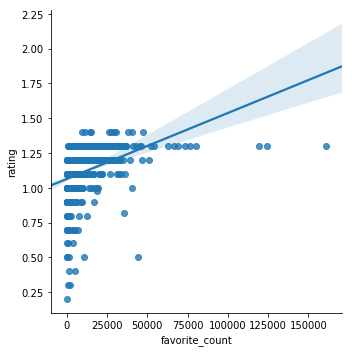

```python
# Create a regression plot of favorite_count with rating
sns.lmplot(y = "rating", x = "favorite_count", data = df_top_rated_breeds);
```

There exists a positive relationship between rating and favorite_count. People give their favorite dog a high rating, or the rating in WeRageDogs does really impact on a person's likeability.

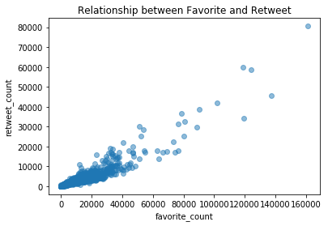

```python
# Create a scatterplot to find the relationship between favorite_count and retweet_count
plt.scatter(y = master_clean['retweet_count'], x = master_clean['favorite_count'], alpha = 0.5)
plt.title("Relationship between Favorite and Retweet")
plt.xlabel("favorite_count")
plt.ylabel("retweet_count");
```

There is a strong correlation between favorite_count and retweet_count. It suggests that if people like it mostly likely they will retweet it.

#### Conclusions

- Based on analysis of data, people like to name their dogs as Charlie, Oliver, and Cooper. The further study can be done on the relationship of the sex of dogs with these popular names.
- Golden retriever and labrador retriever are at the top of list in popularity. Both Pembroke and Chihuahua are also very popular.
- Most likely the popular breeds receive high rating. The rating may have the impact of likeability.
- People tend to retweet their favorite.